# Data wrangling WeRateDogs

## Introduction

The purpose of this project is to put in practice what I learned in data wrangling data section from Udacity Data Analysis Nanodegree program. The dataset that is wrangled is the tweet archive of Twitter user @dog_rates, also known as WeRateDogs.

## Gathering data

1. **Twitter archive file:** download this file manually by clicking the following link: twitter_archive_enhanced.csv
- **The tweet image predictions**, i.e., what breed of dog (or other object, animal, etc.) is present in each tweet according to a neural network. This file (image_predictions.tsv) is hosted on Udacity's servers and should be downloaded programmatically using the Requests library and the following URL: https://d17h27t6h515a5.cloudfront.net/topher/2017/August/599fd2ad_image-predictions/image-predictions.tsv
- **Twitter API & JSON:** Each tweet's retweet count and favorite ("like") count at minimum, and any additional data you find interesting. Using the tweet IDs in the WeRateDogs Twitter archive, query the Twitter API for each tweet's JSON data using Python's Tweepy library and store each tweet's entire set of JSON data in a file called tweet_json.txt file. Each tweet's JSON data should be written to its own line. Then read this .txt file line by line into a pandas DataFrame with (at minimum) tweet ID, retweet count, and favorite count.

**1. Twitter archive file**

```python
#Import all packages needed
import pandas as pd
import numpy as np
import matplotlib.pyplot as plt
%matplotlib inline
import requests
import tweepy
import json
```

```python
#Read CSV file
twitter_archive = pd.read_csv('twitter_archive_enhanced.csv')
```

```python
twitter_archive.sort_values('timestamp')
twitter_archive.head()
```

|  | tweet_id | in_reply_to_status_id | in_reply_to_user_id | timestamp | source | text | retweeted_status_id | retweeted_status_user_id | retweeted_status_timestamp | expanded_urls | rating_numerator | rating_denominator | name | doggo | floofer | pupper | puppo |
| --- | --- | --- | --- | --- | --- | --- | --- | --- | --- | --- | --- | --- | --- | --- | --- | --- | --- |
| 0 | 892420643555336193 | NaN | NaN | 2017-08-01 16:23:56 +0000 | <a href="http://twitter.com/download/iphone" r... | This is Phineas. He's a mystical boy. Only eve... | NaN | NaN | NaN | https://twitter.com/dog_rates/status/892420643... | 13 | 10 | Phineas | None | None | None | None |
| 1 | 892177421306343426 | NaN | NaN | 2017-08-01 00:17:27 +0000 | <a href="http://twitter.com/download/iphone" r... | This is Tilly. She's just checking pup on you.... | NaN | NaN | NaN | https://twitter.com/dog_rates/status/892177421... | 13 | 10 | Tilly | None | None | None | None |
| 2 | 891815181378084864 | NaN | NaN | 2017-07-31 00:18:03 +0000 | <a href="http://twitter.com/download/iphone" r... | This is Archie. He is a rare Norwegian Pouncin... | NaN | NaN | NaN | https://twitter.com/dog_rates/status/891815181... | 12 | 10 | Archie | None | None | None | None |
| 3 | 891689557279858688 | NaN | NaN | 2017-07-30 15:58:51 +0000 | <a href="http://twitter.com/download/iphone" r... | This is Darla. She commenced a snooze mid meal... | NaN | NaN | NaN | https://twitter.com/dog_rates/status/891689557... | 13 | 10 | Darla | None | None | None | None |
| 4 | 891327558926688256 | NaN | NaN | 2017-07-29 16:00:24 +0000 | <a href="http://twitter.com/download/iphone" r... | This is Franklin. He would like you to stop ca... | NaN | NaN | NaN | https://twitter.com/dog_rates/status/891327558... | 12 | 10 | Franklin | None | None | None | None |

```python
twitter_archive.info()
```

```
<class 'pandas.core.frame.DataFrame'>
RangeIndex: 2356 entries, 0 to 2355
Data columns (total 17 columns):
tweet_id                      2356 non-null int64
in_reply_to_status_id         78 non-null float64
in_reply_to_user_id           78 non-null float64
timestamp                     2356 non-null object
source                        2356 non-null object
text                          2356 non-null object
retweeted_status_id           181 non-null float64
retweeted_status_user_id      181 non-null float64
retweeted_status_timestamp    181 non-null object
expanded_urls                 2297 non-null object
rating_numerator              2356 non-null int64
rating_denominator            2356 non-null int64
name                          2356 non-null object
doggo                         2356 non-null object
floofer                       2356 non-null object
pupper                        2356 non-null object
puppo                         2356 non-null object
dtypes: float64(4), int64(3), object(10)
memory usage: 313.0+ KB
```

**2. Tweet image prediction**

```python
#URL downloaded programatically
url = "https://d17h27t6h515a5.cloudfront.net/topher/2017/August/599fd2ad_image-predictions/image-predictions.tsv"
response = requests.get(url)

with open('image_predictions.tsv', mode ='wb') as file:
    file.write(response.content)

#Read TSV file
image_prediction = pd.read_csv('image_predictions.tsv', sep='\t' )
```

```python
#https://stackoverflow.com/questions/28384588/twitter-api-get-tweets-with-specific-id

auth = tweepy.OAuthHandler('5Uur0mo4ol2kB8yhtZ1VxXS0u', 'h8E7fSpXWiMoBel7G1ZOAeu4Mgru0v0MtxH5ehYE1RKM89SiBH')
auth.set_access_token('303562412-ct9aNnU0FQR0UKJVn1i1W3Y8omqSewiQWUcRaygB', 'D3qslrbdOU5fqTOp951kOIuZbkeTPBodnjNYoEGFR63Ft')
api = tweepy.API(auth,
                 parser = tweepy.parsers.JSONParser(),
                 wait_on_rate_limit = True,
                 wait_on_rate_limit_notify = True)
```

**3. Twitter API & JSON**

https://stackoverflow.com/questions/47612822/how-to-create-pandas-dataframe-from-twitter-search-api

```python
# #Download Tweepy status object based on Tweet ID and store in list
# list_of_tweets = []
# # Tweets that can't be found are saved in the list below:
# cant_find_tweets_for_those_ids = []
# for tweet_id in twitter_archive['tweet_id']:
#     try:
#         list_of_tweets.append(api.get_status(tweet_id))
#     except Exception as e:
#         cant_find_tweets_for_those_ids.append(tweet_id)
```

```python
print("The list of tweets" ,len(list_of_tweets))
print("The list of tweets no found" , len(cant_find_tweets_for_those_ids))
```

```
The list of tweets 87
The list of tweets no found 2
```

```python
#Then in this code block we isolate the json part of each tweepy
#status object that we have downloaded and we add them all into a list

my_list_of_dicts = []
for each_json_tweet in list_of_tweets:
    my_list_of_dicts.append(each_json_tweet)
```

```python
#we write this list into a txt file:

with open('tweet_json.txt', 'w') as file:
        file.write(json.dumps(my_list_of_dicts, indent=4))
```

```python
#identify information of interest from JSON dictionaries in txt file
#and put it in a dataframe called tweet JSON
my_demo_list = []
with open('tweet_json.txt', encoding='utf-8') as json_file:
    all_data = json.load(json_file)
    for each_dictionary in all_data:
        tweet_id = each_dictionary['id']
        whole_tweet = each_dictionary['text']
        only_url = whole_tweet[whole_tweet.find('https'):]
        favorite_count = each_dictionary['favorite_count']
        retweet_count = each_dictionary['retweet_count']
        followers_count = each_dictionary['user']['followers_count']
        friends_count = each_dictionary['user']['friends_count']
        whole_source = each_dictionary['source']
        only_device = whole_source[whole_source.find('rel="nofollow">') + 15:-4]
        source = only_device
        retweeted_status = each_dictionary['retweeted_status'] = each_dictionary.get('retweeted_status', 'Original tweet')
        if retweeted_status == 'Original tweet':
            url = only_url
        else:
            retweeted_status = 'This is a retweet'
            url = 'This is a retweet'

        my_demo_list.append({'tweet_id': str(tweet_id),
                             'favorite_count': int(favorite_count),
                             'retweet_count': int(retweet_count),
                             'followers_count': int(followers_count),
                             'friends_count': int(friends_count),
                             'url': url,
                             'source': source,
                             'retweeted_status': retweeted_status,
                            })
        tweet_json = pd.DataFrame(my_demo_list, columns = ['tweet_id', 'favorite_count','retweet_count',
                                                           'followers_count', 'friends_count','source',
                                                           'retweeted_status', 'url'])
```

```python
tweet_json.head()
```

|  | tweet_id | favorite_count | retweet_count | followers_count | friends_count | source | retweeted_status | url |
| --- | --- | --- | --- | --- | --- | --- | --- | --- |
| 0 | 892420643555336193 | 37630 | 8203 | 7966130 | 12 | Twitter for iPhone | Original tweet | https://t.co/MgUWQ76dJU |
| 1 | 892177421306343426 | 32337 | 6070 | 7966130 | 12 | Twitter for iPhone | Original tweet | https://t.co/aQFSeaCu9L |
| 2 | 891815181378084864 | 24365 | 4011 | 7966130 | 12 | Twitter for iPhone | Original tweet | https://t.co/r0YlrsGCgy |
| 3 | 891689557279858688 | 40958 | 8358 | 7966130 | 12 | Twitter for iPhone | Original tweet | https://t.co/tD36da7qLQ |
| 4 | 891327558926688256 | 39159 | 9060 | 7966130 | 12 | Twitter for iPhone | Original tweet | https://t.co/0g0KMIVXZ3 |

```python
tweet_json.info()
```

```
<class 'pandas.core.frame.DataFrame'>
RangeIndex: 87 entries, 0 to 86
Data columns (total 8 columns):
tweet_id            87 non-null object
favorite_count      87 non-null int64
retweet_count       87 non-null int64
followers_count     87 non-null int64
friends_count       87 non-null int64
source              87 non-null object
retweeted_status    87 non-null object
url                 87 non-null object
dtypes: int64(4), object(4)
memory usage: 5.5+ KB
```

## Assessing data

### Visual assessment

Each piece of gathered data is displayed in the Jupyter Notebook for visual assessment purposes.

```python
twitter_archive
```

|  | tweet_id | in_reply_to_status_id | in_reply_to_user_id | timestamp | source | text | retweeted_status_id | retweeted_status_user_id | retweeted_status_timestamp | expanded_urls | rating_numerator | rating_denominator | name | doggo | floofer | pupper | puppo |
| --- | --- | --- | --- | --- | --- | --- | --- | --- | --- | --- | --- | --- | --- | --- | --- | --- | --- |
| 0 | 892420643555336193 | NaN | NaN | 2017-08-01 16:23:56 +0000 | <a href="http://twitter.com/download/iphone" r... | This is Phineas. He's a mystical boy. Only eve... | NaN | NaN | NaN | https://twitter.com/dog_rates/status/892420643... | 13 | 10 | Phineas | None | None | None | None |
| 1 | 892177421306343426 | NaN | NaN | 2017-08-01 00:17:27 +0000 | <a href="http://twitter.com/download/iphone" r... | This is Tilly. She's just checking pup on you.... | NaN | NaN | NaN | https://twitter.com/dog_rates/status/892177421... | 13 | 10 | Tilly | None | None | None | None |
| 2 | 891815181378084864 | NaN | NaN | 2017-07-31 00:18:03 +0000 | <a href="http://twitter.com/download/iphone" r... | This is Archie. He is a rare Norwegian Pouncin... | NaN | NaN | NaN | https://twitter.com/dog_rates/status/891815181... | 12 | 10 | Archie | None | None | None | None |
| 3 | 891689557279858688 | NaN | NaN | 2017-07-30 15:58:51 +0000 | <a href="http://twitter.com/download/iphone" r... | This is Darla. She commenced a snooze mid meal... | NaN | NaN | NaN | https://twitter.com/dog_rates/status/891689557... | 13 | 10 | Darla | None | None | None | None |
| 4 | 891327558926688256 | NaN | NaN | 2017-07-29 16:00:24 +0000 | <a href="http://twitter.com/download/iphone" r... | This is Franklin. He would like you to stop ca... | NaN | NaN | NaN | https://twitter.com/dog_rates/status/891327558... | 12 | 10 | Franklin | None | None | None | None |
| 5 | 891087950875897856 | NaN | NaN | 2017-07-29 00:08:17 +0000 | <a href="http://twitter.com/download/iphone" r... | Here we have a majestic great white breaching ... | NaN | NaN | NaN | https://twitter.com/dog_rates/status/891087950... | 13 | 10 | None | None | None | None | None |
| 6 | 890971913173991426 | NaN | NaN | 2017-07-28 16:27:12 +0000 | <a href="http://twitter.com/download/iphone" r... | Meet Jax. He enjoys ice cream so much he gets ... | NaN | NaN | NaN | https://gofundme.com/ydvmve-surgery-for-jax,ht... | 13 | 10 | Jax | None | None | None | None |
| 7 | 890729181411237888 | NaN | NaN | 2017-07-28 00:22:40 +0000 | <a href="http://twitter.com/download/iphone" r... | When you watch your owner call another dog a g... | NaN | NaN | NaN | https://twitter.com/dog_rates/status/890729181... | 13 | 10 | None | None | None | None | None |
| 8 | 890609185150312448 | NaN | NaN | 2017-07-27 16:25:51 +0000 | <a href="http://twitter.com/download/iphone" r... | This is Zoey. She doesn't want to be one of th... | NaN | NaN | NaN | https://twitter.com/dog_rates/status/890609185... | 13 | 10 | Zoey | None | None | None | None |
| 9 | 890240255349198849 | NaN | NaN | 2017-07-26 15:59:51 +0000 | <a href="http://twitter.com/download/iphone" r... | This is Cassie. She is a college pup. Studying... | NaN | NaN | NaN | https://twitter.com/dog_rates/status/890240255... | 14 | 10 | Cassie | doggo | None | None | None |
| 10 | 890006608113172480 | NaN | NaN | 2017-07-26 00:31:25 +0000 | <a href="http://twitter.com/download/iphone" r... | This is Koda. He is a South Australian decksha... | NaN | NaN | NaN | https://twitter.com/dog_rates/status/890006608... | 13 | 10 | Koda | None | None | None | None |
| 11 | 889880896479866881 | NaN | NaN | 2017-07-25 16:11:53 +0000 | <a href="http://twitter.com/download/iphone" r... | This is Bruno. He is a service shark. Only get... | NaN | NaN | NaN | https://twitter.com/dog_rates/status/889880896... | 13 | 10 | Bruno | None | None | None | None |
| 12 | 889665388333682689 | NaN | NaN | 2017-07-25 01:55:32 +0000 | <a href="http://twitter.com/download/iphone" r... | Here's a puppo that seems to be on the fence a... | NaN | NaN | NaN | https://twitter.com/dog_rates/status/889665388... | 13 | 10 | None | None | None | None | puppo |
| 13 | 889638837579907072 | NaN | NaN | 2017-07-25 00:10:02 +0000 | <a href="http://twitter.com/download/iphone" r... | This is Ted. He does his best. Sometimes that'... | NaN | NaN | NaN | https://twitter.com/dog_rates/status/889638837... | 12 | 10 | Ted | None | None | None | None |
| 14 | 889531135344209921 | NaN | NaN | 2017-07-24 17:02:04 +0000 | <a href="http://twitter.com/download/iphone" r... | This is Stuart. He's sporting his favorite fan... | NaN | NaN | NaN | https://twitter.com/dog_rates/status/889531135... | 13 | 10 | Stuart | None | None | None | puppo |
| 15 | 889278841981685760 | NaN | NaN | 2017-07-24 00:19:32 +0000 | <a href="http://twitter.com/download/iphone" r... | This is Oliver. You're witnessing one of his m... | NaN | NaN | NaN | https://twitter.com/dog_rates/status/889278841... | 13 | 10 | Oliver | None | None | None | None |
| 16 | 888917238123831296 | NaN | NaN | 2017-07-23 00:22:39 +0000 | <a href="http://twitter.com/download/iphone" r... | This is Jim. He found a fren. Taught him how t... | NaN | NaN | NaN | https://twitter.com/dog_rates/status/888917238... | 12 | 10 | Jim | None | None | None | None |
| 17 | 888804989199671297 | NaN | NaN | 2017-07-22 16:56:37 +0000 | <a href="http://twitter.com/download/iphone" r... | This is Zeke. He has a new stick. Very proud o... | NaN | NaN | NaN | https://twitter.com/dog_rates/status/888804989... | 13 | 10 | Zeke | None | None | None | None |
| 18 | 888554962724278272 | NaN | NaN | 2017-07-22 00:23:06 +0000 | <a href="http://twitter.com/download/iphone" r... | This is Ralphus. He's powering up. Attempting ... | NaN | NaN | NaN | https://twitter.com/dog_rates/status/888554962... | 13 | 10 | Ralphus | None | None | None | None |
| 19 | 888202515573088257 | NaN | NaN | 2017-07-21 01:02:36 +0000 | <a href="http://twitter.com/download/iphone" r... | RT @dog_rates: This is Canela. She attempted s... | 8.874740e+17 | 4.196984e+09 | 2017-07-19 00:47:34 +0000 | https://twitter.com/dog_rates/status/887473957... | 13 | 10 | Canela | None | None | None | None |
| 20 | 888078434458587136 | NaN | NaN | 2017-07-20 16:49:33 +0000 | <a href="http://twitter.com/download/iphone" r... | This is Gerald. He was just told he didn't get... | NaN | NaN | NaN | https://twitter.com/dog_rates/status/888078434... | 12 | 10 | Gerald | None | None | None | None |
| 21 | 887705289381826560 | NaN | NaN | 2017-07-19 16:06:48 +0000 | <a href="http://twitter.com/download/iphone" r... | This is Jeffrey. He has a monopoly on the pool... | NaN | NaN | NaN | https://twitter.com/dog_rates/status/887705289... | 13 | 10 | Jeffrey | None | None | None | None |
| 22 | 887517139158093824 | NaN | NaN | 2017-07-19 03:39:09 +0000 | <a href="http://twitter.com/download/iphone" r... | I've yet to rate a Venezuelan Hover Wiener. Th... | NaN | NaN | NaN | https://twitter.com/dog_rates/status/887517139... | 14 | 10 | such | None | None | None | None |
| 23 | 887473957103951883 | NaN | NaN | 2017-07-19 00:47:34 +0000 | <a href="http://twitter.com/download/iphone" r... | This is Canela. She attempted some fancy porch... | NaN | NaN | NaN | https://twitter.com/dog_rates/status/887473957... | 13 | 10 | Canela | None | None | None | None |
| 24 | 887343217045368832 | NaN | NaN | 2017-07-18 16:08:03 +0000 | <a href="http://twitter.com/download/iphone" r... | You may not have known you needed to see this ... | NaN | NaN | NaN | https://twitter.com/dog_rates/status/887343217... | 13 | 10 | None | None | None | None | None |
| 25 | 887101392804085760 | NaN | NaN | 2017-07-18 00:07:08 +0000 | <a href="http://twitter.com/download/iphone" r... | This... is a Jubilant Antarctic House Bear. We... | NaN | NaN | NaN | https://twitter.com/dog_rates/status/887101392... | 12 | 10 | None | None | None | None | None |
| 26 | 886983233522544640 | NaN | NaN | 2017-07-17 16:17:36 +0000 | <a href="http://twitter.com/download/iphone" r... | This is Maya. She's very shy. Rarely leaves he... | NaN | NaN | NaN | https://twitter.com/dog_rates/status/886983233... | 13 | 10 | Maya | None | None | None | None |
| 27 | 886736880519319552 | NaN | NaN | 2017-07-16 23:58:41 +0000 | <a href="http://twitter.com/download/iphone" r... | This is Mingus. He's a wonderful father to his... | NaN | NaN | NaN | https://www.gofundme.com/mingusneedsus,https:/... | 13 | 10 | Mingus | None | None | None | None |
| 28 | 886680336477933568 | NaN | NaN | 2017-07-16 20:14:00 +0000 | <a href="http://twitter.com/download/iphone" r... | This is Derek. He's late for a dog meeting. 13... | NaN | NaN | NaN | https://twitter.com/dog_rates/status/886680336... | 13 | 10 | Derek | None | None | None | None |
| 29 | 886366144734445568 | NaN | NaN | 2017-07-15 23:25:31 +0000 | <a href="http://twitter.com/download/iphone" r... | This is Roscoe. Another pupper fallen victim t... | NaN | NaN | NaN | https://twitter.com/dog_rates/status/886366144... | 12 | 10 | Roscoe | None | None | pupper | None |
| ... | ... | ... | ... | ... | ... | ... | ... | ... | ... | ... | ... | ... | ... | ... | ... | ... | ... |
| 2326 | 666411507551481857 | NaN | NaN | 2015-11-17 00:24:19 +0000 | <a href="http://twitter.com/download/iphone" r... | This is quite the dog. Gets really excited whe... | NaN | NaN | NaN | https://twitter.com/dog_rates/status/666411507... | 2 | 10 | quite | None | None | None | None |
| 2327 | 666407126856765440 | NaN | NaN | 2015-11-17 00:06:54 +0000 | <a href="http://twitter.com/download/iphone" r... | This is a southern Vesuvius bumblegruff. Can d... | NaN | NaN | NaN | https://twitter.com/dog_rates/status/666407126... | 7 | 10 | a | None | None | None | None |
| 2328 | 666396247373291520 | NaN | NaN | 2015-11-16 23:23:41 +0000 | <a href="http://twitter.com/download/iphone" r... | Oh goodness. A super rare northeast Qdoba kang... | NaN | NaN | NaN | https://twitter.com/dog_rates/status/666396247... | 9 | 10 | None | None | None | None | None |
| 2329 | 666373753744588802 | NaN | NaN | 2015-11-16 21:54:18 +0000 | <a href="http://twitter.com/download/iphone" r... | Those are sunglasses and a jean jacket. 11/10 ... | NaN | NaN | NaN | https://twitter.com/dog_rates/status/666373753... | 11 | 10 | None | None | None | None | None |
| 2330 | 666362758909284353 | NaN | NaN | 2015-11-16 21:10:36 +0000 | <a href="http://twitter.com/download/iphone" r... | Unique dog here. Very small. Lives in containe... | NaN | NaN | NaN | https://twitter.com/dog_rates/status/666362758... | 6 | 10 | None | None | None | None | None |
| 2331 | 666353288456101888 | NaN | NaN | 2015-11-16 20:32:58 +0000 | <a href="http://twitter.com/download/iphone" r... | Here we have a mixed Asiago from the Galápagos... | NaN | NaN | NaN | https://twitter.com/dog_rates/status/666353288... | 8 | 10 | None | None | None | None | None |
| 2332 | 666345417576210432 | NaN | NaN | 2015-11-16 20:01:42 +0000 | <a href="http://twitter.com/download/iphone" r... | Look at this jokester thinking seat belt laws ... | NaN | NaN | NaN | https://twitter.com/dog_rates/status/666345417... | 10 | 10 | None | None | None | None | None |
| 2333 | 666337882303524864 | NaN | NaN | 2015-11-16 19:31:45 +0000 | <a href="http://twitter.com/download/iphone" r... | This is an extremely rare horned Parthenon. No... | NaN | NaN | NaN | https://twitter.com/dog_rates/status/666337882... | 9 | 10 | an | None | None | None | None |
| 2334 | 666293911632134144 | NaN | NaN | 2015-11-16 16:37:02 +0000 | <a href="http://twitter.com/download/iphone" r... | This is a funny dog. Weird toes. Won't come do... | NaN | NaN | NaN | https://twitter.com/dog_rates/status/666293911... | 3 | 10 | a | None | None | None | None |
| 2335 | 666287406224695296 | NaN | NaN | 2015-11-16 16:11:11 +0000 | <a href="http://twitter.com/download/iphone" r... | This is an Albanian 3 1/2 legged Episcopalian... | NaN | NaN | NaN | https://twitter.com/dog_rates/status/666287406... | 1 | 2 | an | None | None | None | None |
| 2336 | 666273097616637952 | NaN | NaN | 2015-11-16 15:14:19 +0000 | <a href="http://twitter.com/download/iphone" r... | Can take selfies 11/10 https://t.co/ws2AMaNwPW | NaN | NaN | NaN | https://twitter.com/dog_rates/status/666273097... | 11 | 10 | None | None | None | None | None |
| 2337 | 666268910803644416 | NaN | NaN | 2015-11-16 14:57:41 +0000 | <a href="http://twitter.com/download/iphone" r... | Very concerned about fellow dog trapped in com... | NaN | NaN | NaN | https://twitter.com/dog_rates/status/666268910... | 10 | 10 | None | None | None | None | None |
| 2338 | 666104133288665088 | NaN | NaN | 2015-11-16 04:02:55 +0000 | <a href="http://twitter.com/download/iphone" r... | Not familiar with this breed. No tail (weird).... | NaN | NaN | NaN | https://twitter.com/dog_rates/status/666104133... | 1 | 10 | None | None | None | None | None |
| 2339 | 666102155909144576 | NaN | NaN | 2015-11-16 03:55:04 +0000 | <a href="http://twitter.com/download/iphone" r... | Oh my. Here you are seeing an Adobe Setter giv... | NaN | NaN | NaN | https://twitter.com/dog_rates/status/666102155... | 11 | 10 | None | None | None | None | None |
| 2340 | 666099513787052032 | NaN | NaN | 2015-11-16 03:44:34 +0000 | <a href="http://twitter.com/download/iphone" r... | Can stand on stump for what seems like a while... | NaN | NaN | NaN | https://twitter.com/dog_rates/status/666099513... | 8 | 10 | None | None | None | None | None |
| 2341 | 666094000022159362 | NaN | NaN | 2015-11-16 03:22:39 +0000 | <a href="http://twitter.com/download/iphone" r... | This appears to be a Mongolian Presbyterian mi... | NaN | NaN | NaN | https://twitter.com/dog_rates/status/666094000... | 9 | 10 | None | None | None | None | None |
| 2342 | 666082916733198337 | NaN | NaN | 2015-11-16 02:38:37 +0000 | <a href="http://twitter.com/download/iphone" r... | Here we have a well-established sunblockerspan... | NaN | NaN | NaN | https://twitter.com/dog_rates/status/666082916... | 6 | 10 | None | None | None | None | None |
| 2343 | 666073100786774016 | NaN | NaN | 2015-11-16 01:59:36 +0000 | <a href="http://twitter.com/download/iphone" r... | Let's hope this flight isn't Malaysian (lol). ... | NaN | NaN | NaN | https://twitter.com/dog_rates/status/666073100... | 10 | 10 | None | None | None | None | None |
| 2344 | 666071193221509120 | NaN | NaN | 2015-11-16 01:52:02 +0000 | <a href="http://twitter.com/download/iphone" r... | Here we have a northern speckled Rhododendron.... | NaN | NaN | NaN | https://twitter.com/dog_rates/status/666071193... | 9 | 10 | None | None | None | None | None |
| 2345 | 666063827256086533 | NaN | NaN | 2015-11-16 01:22:45 +0000 | <a href="http://twitter.com/download/iphone" r... | This is the happiest dog you will ever see. Ve... | NaN | NaN | NaN | https://twitter.com/dog_rates/status/666063827... | 10 | 10 | the | None | None | None | None |
| 2346 | 666058600524156928 | NaN | NaN | 2015-11-16 01:01:59 +0000 | <a href="http://twitter.com/download/iphone" r... | Here is the Rand Paul of retrievers folks! He'... | NaN | NaN | NaN | https://twitter.com/dog_rates/status/666058600... | 8 | 10 | the | None | None | None | None |
| 2347 | 666057090499244032 | NaN | NaN | 2015-11-16 00:55:59 +0000 | <a href="http://twitter.com/download/iphone" r... | My oh my. This is a rare blond Canadian terrie... | NaN | NaN | NaN | https://twitter.com/dog_rates/status/666057090... | 9 | 10 | a | None | None | None | None |
| 2348 | 666055525042405380 | NaN | NaN | 2015-11-16 00:49:46 +0000 | <a href="http://twitter.com/download/iphone" r... | Here is a Siberian heavily armored polar bear ... | NaN | NaN | NaN | https://twitter.com/dog_rates/status/666055525... | 10 | 10 | a | None | None | None | None |
| 2349 | 666051853826850816 | NaN | NaN | 2015-11-16 00:35:11 +0000 | <a href="http://twitter.com/download/iphone" r... | This is an odd dog. Hard on the outside but lo... | NaN | NaN | NaN | https://twitter.com/dog_rates/status/666051853... | 2 | 10 | an | None | None | None | None |
| 2350 | 666050758794694657 | NaN | NaN | 2015-11-16 00:30:50 +0000 | <a href="http://twitter.com/download/iphone" r... | This is a truly beautiful English Wilson Staff... | NaN | NaN | NaN | https://twitter.com/dog_rates/status/666050758... | 10 | 10 | a | None | None | None | None |
| 2351 | 666049248165822465 | NaN | NaN | 2015-11-16 00:24:50 +0000 | <a href="http://twitter.com/download/iphone" r... | Here we have a 1949 1st generation vulpix. Enj... | NaN | NaN | NaN | https://twitter.com/dog_rates/status/666049248... | 5 | 10 | None | None | None | None | None |
| 2352 | 666044226329800704 | NaN | NaN | 2015-11-16 00:04:52 +0000 | <a href="http://twitter.com/download/iphone" r... | This is a purebred Piers Morgan. Loves to Netf... | NaN | NaN | NaN | https://twitter.com/dog_rates/status/666044226... | 6 | 10 | a | None | None | None | None |
| 2353 | 666033412701032449 | NaN | NaN | 2015-11-15 23:21:54 +0000 | <a href="http://twitter.com/download/iphone" r... | Here is a very happy pup. Big fan of well-main... | NaN | NaN | NaN | https://twitter.com/dog_rates/status/666033412... | 9 | 10 | a | None | None | None | None |
| 2354 | 666029285002620928 | NaN | NaN | 2015-11-15 23:05:30 +0000 | <a href="http://twitter.com/download/iphone" r... | This is a western brown Mitsubishi terrier. Up... | NaN | NaN | NaN | https://twitter.com/dog_rates/status/666029285... | 7 | 10 | a | None | None | None | None |
| 2355 | 666020888022790149 | NaN | NaN | 2015-11-15 22:32:08 +0000 | <a href="http://twitter.com/download/iphone" r... | Here we have a Japanese Irish Setter. Lost eye... | NaN | NaN | NaN | https://twitter.com/dog_rates/status/666020888... | 8 | 10 | None | None | None | None | None |

2356 rows × 17 columns

```python
image_prediction
```

|  | tweet_id | jpg_url | img_num | p1 | p1_conf | p1_dog | p2 | p2_conf | p2_dog | p3 | p3_conf | p3_dog |
| --- | --- | --- | --- | --- | --- | --- | --- | --- | --- | --- | --- | --- |
| 0 | 666020888022790149 | https://pbs.twimg.com/media/CT4udn0WwAA0aMy.jpg | 1 | Welsh_springer_spaniel | 0.465074 | True | collie | 0.156665 | True | Shetland_sheepdog | 0.061428 | True |
| 1 | 666029285002620928 | https://pbs.twimg.com/media/CT42GRgUYAA5iDo.jpg | 1 | redbone | 0.506826 | True | miniature_pinscher | 0.074192 | True | Rhodesian_ridgeback | 0.072010 | True |
| 2 | 666033412701032449 | https://pbs.twimg.com/media/CT4521TWwAEvMyu.jpg | 1 | German_shepherd | 0.596461 | True | malinois | 0.138584 | True | bloodhound | 0.116197 | True |
| 3 | 666044226329800704 | https://pbs.twimg.com/media/CT5Dr8HUEAA-lEu.jpg | 1 | Rhodesian_ridgeback | 0.408143 | True | redbone | 0.360687 | True | miniature_pinscher | 0.222752 | True |
| 4 | 666049248165822465 | https://pbs.twimg.com/media/CT5IQmsXIAAKY4A.jpg | 1 | miniature_pinscher | 0.560311 | True | Rottweiler | 0.243682 | True | Doberman | 0.154629 | True |
| 5 | 666050758794694657 | https://pbs.twimg.com/media/CT5Jof1WUAEuVxN.jpg | 1 | Bernese_mountain_dog | 0.651137 | True | English_springer | 0.263788 | True | Greater_Swiss_Mountain_dog | 0.016199 | True |
| 6 | 666051853826850816 | https://pbs.twimg.com/media/CT5KoJ1WoAAJash.jpg | 1 | box_turtle | 0.933012 | False | mud_turtle | 0.045885 | False | terrapin | 0.017885 | False |
| 7 | 666055525042405380 | https://pbs.twimg.com/media/CT5N9tpXIAAifs1.jpg | 1 | chow | 0.692517 | True | Tibetan_mastiff | 0.058279 | True | fur_coat | 0.054449 | False |
| 8 | 666057090499244032 | https://pbs.twimg.com/media/CT5PY90WoAAQGLo.jpg | 1 | shopping_cart | 0.962465 | False | shopping_basket | 0.014594 | False | golden_retriever | 0.007959 | True |
| 9 | 666058600524156928 | https://pbs.twimg.com/media/CT5Qw94XAAA_2dP.jpg | 1 | miniature_poodle | 0.201493 | True | komondor | 0.192305 | True | soft-coated_wheaten_terrier | 0.082086 | True |
| 10 | 666063827256086533 | https://pbs.twimg.com/media/CT5Vg_wXIAAXfnj.jpg | 1 | golden_retriever | 0.775930 | True | Tibetan_mastiff | 0.093718 | True | Labrador_retriever | 0.072427 | True |
| 11 | 666071193221509120 | https://pbs.twimg.com/media/CT5cN_3WEAAlOoZ.jpg | 1 | Gordon_setter | 0.503672 | True | Yorkshire_terrier | 0.174201 | True | Pekinese | 0.109454 | True |
| 12 | 666073100786774016 | https://pbs.twimg.com/media/CT5d9DZXAAALcwe.jpg | 1 | Walker_hound | 0.260857 | True | English_foxhound | 0.175382 | True | Ibizan_hound | 0.097471 | True |
| 13 | 666082916733198337 | https://pbs.twimg.com/media/CT5m4VGWEAAtKc8.jpg | 1 | pug | 0.489814 | True | bull_mastiff | 0.404722 | True | French_bulldog | 0.048960 | True |
| 14 | 666094000022159362 | https://pbs.twimg.com/media/CT5w9gUW4AAsBNN.jpg | 1 | bloodhound | 0.195217 | True | German_shepherd | 0.078260 | True | malinois | 0.075628 | True |
| 15 | 666099513787052032 | https://pbs.twimg.com/media/CT51-JJUEAA6hV8.jpg | 1 | Lhasa | 0.582330 | True | Shih-Tzu | 0.166192 | True | Dandie_Dinmont | 0.089688 | True |
| 16 | 666102155909144576 | https://pbs.twimg.com/media/CT54YGiWUAEZnoK.jpg | 1 | English_setter | 0.298617 | True | Newfoundland | 0.149842 | True | borzoi | 0.133649 | True |
| 17 | 666104133288665088 | https://pbs.twimg.com/media/CT56LSZWoAAlJj2.jpg | 1 | hen | 0.965932 | False | cock | 0.033919 | False | partridge | 0.000052 | False |
| 18 | 666268910803644416 | https://pbs.twimg.com/media/CT8QCd1WEAADXws.jpg | 1 | desktop_computer | 0.086502 | False | desk | 0.085547 | False | bookcase | 0.079480 | False |
| 19 | 666273097616637952 | https://pbs.twimg.com/media/CT8T1mtUwAA3aqm.jpg | 1 | Italian_greyhound | 0.176053 | True | toy_terrier | 0.111884 | True | basenji | 0.111152 | True |
| 20 | 666287406224695296 | https://pbs.twimg.com/media/CT8g3BpUEAAuFjg.jpg | 1 | Maltese_dog | 0.857531 | True | toy_poodle | 0.063064 | True | miniature_poodle | 0.025581 | True |
| 21 | 666293911632134144 | https://pbs.twimg.com/media/CT8mx7KW4AEQu8N.jpg | 1 | three-toed_sloth | 0.914671 | False | otter | 0.015250 | False | great_grey_owl | 0.013207 | False |
| 22 | 666337882303524864 | https://pbs.twimg.com/media/CT9OwFIWEAMuRje.jpg | 1 | ox | 0.416669 | False | Newfoundland | 0.278407 | True | groenendael | 0.102643 | True |
| 23 | 666345417576210432 | https://pbs.twimg.com/media/CT9Vn7PWoAA_ZCM.jpg | 1 | golden_retriever | 0.858744 | True | Chesapeake_Bay_retriever | 0.054787 | True | Labrador_retriever | 0.014241 | True |
| 24 | 666353288456101888 | https://pbs.twimg.com/media/CT9cx0tUEAAhNN_.jpg | 1 | malamute | 0.336874 | True | Siberian_husky | 0.147655 | True | Eskimo_dog | 0.093412 | True |
| 25 | 666362758909284353 | https://pbs.twimg.com/media/CT9lXGsUcAAyUFt.jpg | 1 | guinea_pig | 0.996496 | False | skunk | 0.002402 | False | hamster | 0.000461 | False |
| 26 | 666373753744588802 | https://pbs.twimg.com/media/CT9vZEYWUAAlZ05.jpg | 1 | soft-coated_wheaten_terrier | 0.326467 | True | Afghan_hound | 0.259551 | True | briard | 0.206803 | True |
| 27 | 666396247373291520 | https://pbs.twimg.com/media/CT-D2ZHWIAA3gK1.jpg | 1 | Chihuahua | 0.978108 | True | toy_terrier | 0.009397 | True | papillon | 0.004577 | True |
| 28 | 666407126856765440 | https://pbs.twimg.com/media/CT-NvwmW4AAugGZ.jpg | 1 | black-and-tan_coonhound | 0.529139 | True | bloodhound | 0.244220 | True | flat-coated_retriever | 0.173810 | True |
| 29 | 666411507551481857 | https://pbs.twimg.com/media/CT-RugiWIAELEaq.jpg | 1 | coho | 0.404640 | False | barracouta | 0.271485 | False | gar | 0.189945 | False |
| ... | ... | ... | ... | ... | ... | ... | ... | ... | ... | ... | ... | ... |
| 2045 | 886366144734445568 | https://pbs.twimg.com/media/DE0BTnQUwAApKEH.jpg | 1 | French_bulldog | 0.999201 | True | Chihuahua | 0.000361 | True | Boston_bull | 0.000076 | True |
| 2046 | 886680336477933568 | https://pbs.twimg.com/media/DE4fEDzWAAAyHMM.jpg | 1 | convertible | 0.738995 | False | sports_car | 0.139952 | False | car_wheel | 0.044173 | False |
| 2047 | 886736880519319552 | https://pbs.twimg.com/media/DE5Se8FXcAAJFx4.jpg | 1 | kuvasz | 0.309706 | True | Great_Pyrenees | 0.186136 | True | Dandie_Dinmont | 0.086346 | True |
| 2048 | 886983233522544640 | https://pbs.twimg.com/media/DE8yicJW0AAAvBJ.jpg | 2 | Chihuahua | 0.793469 | True | toy_terrier | 0.143528 | True | can_opener | 0.032253 | False |
| 2049 | 887101392804085760 | https://pbs.twimg.com/media/DE-eAq6UwAA-jaE.jpg | 1 | Samoyed | 0.733942 | True | Eskimo_dog | 0.035029 | True | Staffordshire_bullterrier | 0.029705 | True |
| 2050 | 887343217045368832 | https://pbs.twimg.com/ext_tw_video_thumb/88734... | 1 | Mexican_hairless | 0.330741 | True | sea_lion | 0.275645 | False | Weimaraner | 0.134203 | True |
| 2051 | 887473957103951883 | https://pbs.twimg.com/media/DFDw2tyUQAAAFke.jpg | 2 | Pembroke | 0.809197 | True | Rhodesian_ridgeback | 0.054950 | True | beagle | 0.038915 | True |
| 2052 | 887517139158093824 | https://pbs.twimg.com/ext_tw_video_thumb/88751... | 1 | limousine | 0.130432 | False | tow_truck | 0.029175 | False | shopping_cart | 0.026321 | False |
| 2053 | 887705289381826560 | https://pbs.twimg.com/media/DFHDQBbXgAEqY7t.jpg | 1 | basset | 0.821664 | True | redbone | 0.087582 | True | Weimaraner | 0.026236 | True |
| 2054 | 888078434458587136 | https://pbs.twimg.com/media/DFMWn56WsAAkA7B.jpg | 1 | French_bulldog | 0.995026 | True | pug | 0.000932 | True | bull_mastiff | 0.000903 | True |
| 2055 | 888202515573088257 | https://pbs.twimg.com/media/DFDw2tyUQAAAFke.jpg | 2 | Pembroke | 0.809197 | True | Rhodesian_ridgeback | 0.054950 | True | beagle | 0.038915 | True |
| 2056 | 888554962724278272 | https://pbs.twimg.com/media/DFTH_O-UQAACu20.jpg | 3 | Siberian_husky | 0.700377 | True | Eskimo_dog | 0.166511 | True | malamute | 0.111411 | True |
| 2057 | 888804989199671297 | https://pbs.twimg.com/media/DFWra-3VYAA2piG.jpg | 1 | golden_retriever | 0.469760 | True | Labrador_retriever | 0.184172 | True | English_setter | 0.073482 | True |
| 2058 | 888917238123831296 | https://pbs.twimg.com/media/DFYRgsOUQAARGhO.jpg | 1 | golden_retriever | 0.714719 | True | Tibetan_mastiff | 0.120184 | True | Labrador_retriever | 0.105506 | True |
| 2059 | 889278841981685760 | https://pbs.twimg.com/ext_tw_video_thumb/88927... | 1 | whippet | 0.626152 | True | borzoi | 0.194742 | True | Saluki | 0.027351 | True |
| 2060 | 889531135344209921 | https://pbs.twimg.com/media/DFg_2PVW0AEHN3p.jpg | 1 | golden_retriever | 0.953442 | True | Labrador_retriever | 0.013834 | True | redbone | 0.007958 | True |
| 2061 | 889638837579907072 | https://pbs.twimg.com/media/DFihzFfXsAYGDPR.jpg | 1 | French_bulldog | 0.991650 | True | boxer | 0.002129 | True | Staffordshire_bullterrier | 0.001498 | True |
| 2062 | 889665388333682689 | https://pbs.twimg.com/media/DFi579UWsAAatzw.jpg | 1 | Pembroke | 0.966327 | True | Cardigan | 0.027356 | True | basenji | 0.004633 | True |
| 2063 | 889880896479866881 | https://pbs.twimg.com/media/DFl99B1WsAITKsg.jpg | 1 | French_bulldog | 0.377417 | True | Labrador_retriever | 0.151317 | True | muzzle | 0.082981 | False |
| 2064 | 890006608113172480 | https://pbs.twimg.com/media/DFnwSY4WAAAMliS.jpg | 1 | Samoyed | 0.957979 | True | Pomeranian | 0.013884 | True | chow | 0.008167 | True |
| 2065 | 890240255349198849 | https://pbs.twimg.com/media/DFrEyVuW0AAO3t9.jpg | 1 | Pembroke | 0.511319 | True | Cardigan | 0.451038 | True | Chihuahua | 0.029248 | True |
| 2066 | 890609185150312448 | https://pbs.twimg.com/media/DFwUU__XcAEpyXI.jpg | 1 | Irish_terrier | 0.487574 | True | Irish_setter | 0.193054 | True | Chesapeake_Bay_retriever | 0.118184 | True |
| 2067 | 890729181411237888 | https://pbs.twimg.com/media/DFyBahAVwAAhUTd.jpg | 2 | Pomeranian | 0.566142 | True | Eskimo_dog | 0.178406 | True | Pembroke | 0.076507 | True |
| 2068 | 890971913173991426 | https://pbs.twimg.com/media/DF1eOmZXUAALUcq.jpg | 1 | Appenzeller | 0.341703 | True | Border_collie | 0.199287 | True | ice_lolly | 0.193548 | False |
| 2069 | 891087950875897856 | https://pbs.twimg.com/media/DF3HwyEWsAABqE6.jpg | 1 | Chesapeake_Bay_retriever | 0.425595 | True | Irish_terrier | 0.116317 | True | Indian_elephant | 0.076902 | False |
| 2070 | 891327558926688256 | https://pbs.twimg.com/media/DF6hr6BUMAAzZgT.jpg | 2 | basset | 0.555712 | True | English_springer | 0.225770 | True | German_short-haired_pointer | 0.175219 | True |
| 2071 | 891689557279858688 | https://pbs.twimg.com/media/DF_q7IAWsAEuuN8.jpg | 1 | paper_towel | 0.170278 | False | Labrador_retriever | 0.168086 | True | spatula | 0.040836 | False |
| 2072 | 891815181378084864 | https://pbs.twimg.com/media/DGBdLU1WsAANxJ9.jpg | 1 | Chihuahua | 0.716012 | True | malamute | 0.078253 | True | kelpie | 0.031379 | True |
| 2073 | 892177421306343426 | https://pbs.twimg.com/media/DGGmoV4XsAAUL6n.jpg | 1 | Chihuahua | 0.323581 | True | Pekinese | 0.090647 | True | papillon | 0.068957 | True |
| 2074 | 892420643555336193 | https://pbs.twimg.com/media/DGKD1-bXoAAIAUK.jpg | 1 | orange | 0.097049 | False | bagel | 0.085851 | False | banana | 0.076110 | False |

2075 rows × 12 columns

```python
tweet_json
```

|  | tweet_id | favorite_count | retweet_count | followers_count | friends_count | source | retweeted_status | url |
| --- | --- | --- | --- | --- | --- | --- | --- | --- |
| 0 | 892420643555336193 | 37630 | 8203 | 7966130 | 12 | Twitter for iPhone | Original tweet | https://t.co/MgUWQ76dJU |
| 1 | 892177421306343426 | 32337 | 6070 | 7966130 | 12 | Twitter for iPhone | Original tweet | https://t.co/aQFSeaCu9L |
| 2 | 891815181378084864 | 24365 | 4011 | 7966130 | 12 | Twitter for iPhone | Original tweet | https://t.co/r0YlrsGCgy |
| 3 | 891689557279858688 | 40958 | 8358 | 7966130 | 12 | Twitter for iPhone | Original tweet | https://t.co/tD36da7qLQ |
| 4 | 891327558926688256 | 39159 | 9060 | 7966130 | 12 | Twitter for iPhone | Original tweet | https://t.co/0g0KMIVXZ3 |
| 5 | 891087950875897856 | 19691 | 3005 | 7966130 | 12 | Twitter for iPhone | Original tweet | https://t.co/xx5cilW0Dd |
| 6 | 890971913173991426 | 11513 | 1988 | 7966130 | 12 | Twitter for iPhone | Original tweet | https://t.co/MV01Q820LT |
| 7 | 890729181411237888 | 63499 | 18231 | 7966130 | 12 | Twitter for iPhone | Original tweet | https://t.co/hrcFOGi12V |
| 8 | 890609185150312448 | 27078 | 4129 | 7966130 | 12 | Twitter for iPhone | Original tweet | https://t.co/UkrdQyoYxV |
| 9 | 890240255349198849 | 31026 | 7125 | 7966130 | 12 | Twitter for iPhone | Original tweet | https://t.co/l3TSS3o2M0 |
| 10 | 890006608113172480 | 29850 | 7084 | 7966130 | 12 | Twitter for iPhone | Original tweet | https://t.co/jy2alqaYPH |
| 11 | 889880896479866881 | 27057 | 4813 | 7966130 | 12 | Twitter for iPhone | Original tweet | https://t.co/u1XPQMl29g |
| 12 | 889665388333682689 | 46789 | 9703 | 7966130 | 12 | Twitter for iPhone | Original tweet | https://t.co/BxvuXk0UCm |
| 13 | 889638837579907072 | 26375 | 4381 | 7966130 | 12 | Twitter for iPhone | Original tweet | https://t.co/f8dEDcrKSR |
| 14 | 889531135344209921 | 14711 | 2176 | 7966130 | 12 | Twitter for iPhone | Original tweet | https://t.co/Ya3bdfYuCx |
| 15 | 889278841981685760 | 24566 | 5198 | 7966130 | 12 | Twitter for iPhone | Original tweet | https://t.co/qw5xRwBaIv |
| 16 | 888917238123831296 | 28338 | 4351 | 7966130 | 12 | Twitter for iPhone | Original tweet | https://t.co/chxruIOUJN |
| 17 | 888804989199671297 | 24855 | 4134 | 7966131 | 12 | Twitter for iPhone | Original tweet | https://t.co/L5cCoR2huQ |
| 18 | 888554962724278272 | 19290 | 3421 | 7966131 | 12 | Twitter for iPhone | Original tweet | https://t.co/YnYAFCTTiK |
| 19 | 888078434458587136 | 21177 | 3369 | 7966131 | 12 | Twitter for iPhone | Original tweet | https://t.co/UibDBnVpvR |
| 20 | 887705289381826560 | 29386 | 5200 | 7966131 | 12 | Twitter for iPhone | Original tweet | https://t.co/m7BR4JgDrZ |
| 21 | 887517139158093824 | 45037 | 11312 | 7966131 | 12 | Twitter for iPhone | Original tweet | https://t.co/20VrLAA8ba |
| 22 | 887473957103951883 | 67060 | 17551 | 7966131 | 12 | Twitter for iPhone | Original tweet | https://t.co/cLyzpcUcMX |
| 23 | 887343217045368832 | 32760 | 10076 | 7966131 | 12 | Twitter for iPhone | Original tweet | https://t.co/WZqNqygEyV |
| 24 | 887101392804085760 | 29749 | 5759 | 7966131 | 12 | Twitter for iPhone | Original tweet | https://t.co/UgW2xbO7Rg |
| 25 | 886983233522544640 | 34167 | 7510 | 7966132 | 12 | Twitter for iPhone | Original tweet | https://t.co/I6oNy0CgiT |
| 26 | 886736880519319552 | 11717 | 3159 | 7966132 | 12 | Twitter for iPhone | Original tweet | https://t.co/RipKYZ0T1u |
| 27 | 886680336477933568 | 21845 | 4317 | 7966132 | 12 | Twitter for iPhone | Original tweet | https://t.co/BCoWue0abA |
| 28 | 886366144734445568 | 20614 | 3095 | 7966132 | 12 | Twitter for iPhone | Original tweet | https://t.co/iIu3AF8IWH |
| 29 | 886267009285017600 | 116 | 4 | 7966132 | 12 | Twitter for iPhone | Original tweet | n |
| ... | ... | ... | ... | ... | ... | ... | ... | ... |
| 57 | 880935762899988482 | 16599 | 2701 | 7966134 | 12 | Twitter for iPhone | Original tweet | https://t.co/D0wb1GlKAt |
| 58 | 880872448815771648 | 20698 | 3710 | 7966134 | 12 | Twitter for iPhone | Original tweet | https://t.co/1nxJLhk0Sd |
| 59 | 880465832366813184 | 27769 | 6086 | 7966135 | 12 | Twitter for iPhone | Original tweet | https://t.co/4VsFysDmiw |
| 60 | 880221127280381952 | 26300 | 4087 | 7966135 | 12 | Twitter for iPhone | Original tweet | https://t.co/fUod0tVmvK |
| 61 | 880095782870896641 | 26890 | 4207 | 7966135 | 12 | Twitter for iPhone | Original tweet | https://t.co/yxYE3cWcCP |
| 62 | 879862464715927552 | 21755 | 3388 | 7966136 | 12 | Twitter for iPhone | Original tweet | https://t.co/Qh5aEkRQm9 |
| 63 | 879674319642796034 | 302 | 10 | 7966136 | 12 | Twitter for iPhone | Original tweet | d |
| 64 | 879492040517615616 | 22812 | 3081 | 7966136 | 12 | Twitter for iPhone | Original tweet | https://t.co/IxM9IMKQq8 |
| 65 | 879415818425184262 | 103014 | 42918 | 7966136 | 12 | Twitter for iPhone | Original tweet | https://t.co/UDT7ZkcTgY |
| 66 | 879376492567855104 | 16369 | 3018 | 7966136 | 12 | Twitter for iPhone | Original tweet | https://t.co/RqUrIisQta |
| 67 | 879130579576475649 | 0 | 6603 | 7966136 | 12 | Twitter for iPhone | This is a retweet | This is a retweet |
| 68 | 879050749262655488 | 21952 | 4559 | 7966136 | 12 | Twitter for iPhone | Original tweet | https://t.co/ffTAMZt2n7 |
| 69 | 879008229531029506 | 18491 | 2613 | 7966136 | 12 | Twitter for iPhone | Original tweet | https://t.co/YDtpCjIPKN |
| 70 | 878776093423087618 | 18905 | 4003 | 7966136 | 12 | Twitter for iPhone | Original tweet | https://t.co/0Uxl9Gq7hN |
| 71 | 878604707211726852 | 29416 | 6979 | 7966136 | 12 | Twitter for iPhone | Original tweet | https://t.co/9uABQXgjwa |
| 72 | 878404777348136964 | 0 | 1248 | 7966136 | 12 | Twitter for iPhone | This is a retweet | This is a retweet |
| 73 | 878316110768087041 | 0 | 6447 | 7966136 | 12 | Twitter for iPhone | This is a retweet | This is a retweet |
| 74 | 878281511006478336 | 7537 | 1248 | 7966136 | 12 | Twitter for iPhone | Original tweet | https://t.co/5HuiInQveF |
| 75 | 878057613040115712 | 40954 | 6603 | 7966136 | 12 | Twitter for iPhone | Original tweet | https://t.co/cwtWnHMVpe |
| 76 | 877736472329191424 | 77559 | 18518 | 7966136 | 12 | Twitter for iPhone | Original tweet | https://t.co/lsPyyAiF1r |
| 77 | 877611172832227328 | 0 | 78 | 7966137 | 12 | Twitter for iPhone | This is a retweet | This is a retweet |
| 78 | 877556246731214848 | 22143 | 3693 | 7966137 | 12 | Twitter for iPhone | Original tweet | https://t.co/rc53DmRHwK |
| 79 | 877316821321428993 | 26698 | 5041 | 7966137 | 12 | Twitter for iPhone | Original tweet | https://t.co/tVXlmh3uX3 |
| 80 | 877201837425926144 | 26430 | 5426 | 7966137 | 12 | Twitter for iPhone | Original tweet | https://t.co/kVwm88J6Yr |
| 81 | 876537666061221889 | 22948 | 4508 | 7966138 | 12 | Twitter for iPhone | Original tweet | https://t.co/ghfhFSYrMm |
| 82 | 876484053909872640 | 18288 | 2324 | 7966138 | 12 | Twitter for iPhone | Original tweet | https://t.co/ccBFQU5UWO |
| 83 | 876120275196170240 | 27240 | 4550 | 7966138 | 12 | Twitter for iPhone | Original tweet | https://t.co/9NqZV4WwyX |
| 84 | 875747767867523072 | 24563 | 4165 | 7966138 | 12 | Twitter for iPhone | Original tweet | https://t.co/XRwtpQiJ15 |
| 85 | 875144289856114688 | 21387 | 4805 | 7966138 | 12 | Twitter for iPhone | Original tweet | https://t.co/wK0pt8Cnck |
| 86 | 875097192612077568 | 26726 | 5895 | 7966138 | 12 | Twitter for iPhone | Original tweet | https://t.co/PFp4MghzBW |

87 rows × 8 columns

### Programmatic assessment

Pandas' functions and/or methods are used to assess the data.

```python
twitter_archive.info()
```

```
<class 'pandas.core.frame.DataFrame'>
RangeIndex: 2356 entries, 0 to 2355
Data columns (total 17 columns):
tweet_id                      2356 non-null int64
in_reply_to_status_id         78 non-null float64
in_reply_to_user_id           78 non-null float64
timestamp                     2356 non-null object
source                        2356 non-null object
text                          2356 non-null object
retweeted_status_id           181 non-null float64
retweeted_status_user_id      181 non-null float64
retweeted_status_timestamp    181 non-null object
expanded_urls                 2297 non-null object
rating_numerator              2356 non-null int64
rating_denominator            2356 non-null int64
name                          2356 non-null object
doggo                         2356 non-null object
floofer                       2356 non-null object
pupper                        2356 non-null object
puppo                         2356 non-null object
dtypes: float64(4), int64(3), object(10)
memory usage: 313.0+ KB
```

```python
sum(twitter_archive['tweet_id'].duplicated())
```

```
0
```

```python
twitter_archive.rating_numerator.value_counts()
```

```
12      558
11      464
10      461
13      351
9       158
8       102
7        55
14       54
5        37
6        32
3        19
4        17
1         9
2         9
420       2
```

[output cut: 26 more lines]

```python
print(twitter_archive.loc[twitter_archive.rating_numerator == 204, 'text'])
print(twitter_archive.loc[twitter_archive.rating_numerator == 143, 'text'])
print(twitter_archive.loc[twitter_archive.rating_numerator == 666, 'text'])
print(twitter_archive.loc[twitter_archive.rating_numerator == 1176, 'text'])
print(twitter_archive.loc[twitter_archive.rating_numerator == 144, 'text'])
```

```
1120    Say hello to this unbelievably well behaved sq...
Name: text, dtype: object
1634    Two sneaky puppers were not initially seen, mo...
Name: text, dtype: object
189    @s8n You tried very hard to portray this good ...
Name: text, dtype: object
Series([], Name: text, dtype: object)
1779    IT'S PUPPERGEDDON. Total of 144/120 ...I think...
Name: text, dtype: object
```

```python
#print whole text in order to verify numerators and denominators
print(twitter_archive['text'][1120]) #17 dogs
print(twitter_archive['text'][1634]) #13 dogs
print(twitter_archive['text'][313]) #just a tweet to explain actual ratings, this will be ignored when cleaning data
print(twitter_archive['text'][189]) #no picture, this will be ignored when cleaning data
print(twitter_archive['text'][1779]) #12 dogs
```

```
Say hello to this unbelievably well behaved squad of doggos. 204/170 would try to pet all at once https://t.co/yGQI3He3xv
Two sneaky puppers were not initially seen, moving the rating to 143/130. Please forgive us. Thank you https://t.co/kRK51Y5ac3
@jonnysun @Lin_Manuel ok jomny I know you're excited but 960/00 isn't a valid rating, 13/10 is tho
@s8n You tried very hard to portray this good boy as not so good, but you have ultimately failed. His goodness shines through. 666/10
IT'S PUPPERGEDDON. Total of 144/120 ...I think https://t.co/ZanVtAtvIq
```

```python
twitter_archive.rating_denominator.value_counts()
```

```
10     2333
11        3
50        3
80        2
20        2
2         1
16        1
40        1
70        1
15        1
90        1
110       1
120       1
130       1
150       1
170       1
7         1
0         1
Name: rating_denominator, dtype: int64
```

```python
print(twitter_archive.loc[twitter_archive.rating_denominator == 11, 'text'])
print(twitter_archive.loc[twitter_archive.rating_denominator == 2, 'text'])
print(twitter_archive.loc[twitter_archive.rating_denominator == 16, 'text'])
print(twitter_archive.loc[twitter_archive.rating_denominator == 15, 'text'])
print(twitter_archive.loc[twitter_archive.rating_denominator == 7, 'text'])
```

```
784     RT @dog_rates: After so many requests, this is...
1068    After so many requests, this is Bretagne. She ...
1662    This is Darrel. He just robbed a 7/11 and is i...
Name: text, dtype: object
2335    This is an Albanian 3 1/2 legged  Episcopalian...
Name: text, dtype: object
1663    I'm aware that I could've said 20/16, but here...
Name: text, dtype: object
342    @docmisterio account started on 11/15/15
Name: text, dtype: object
516    Meet Sam. She smiles 24/7 &amp; secretly aspir...
Name: text, dtype: object
```

```python
print(twitter_archive['text'][784]) #retweet - it will be deleted when delete all retweets
print(twitter_archive['text'][1068]) #actual rating 14/10 need to change manually
print(twitter_archive['text'][1662]) #actual rating 10/10 need to change manually
print(twitter_archive['text'][2335]) #actual rating 9/10 need to change manually
print(twitter_archive['text'][1663]) # tweet to explain rating
print(twitter_archive['text'][342]) #no rating - delete
print(twitter_archive['text'][516]) #no rating - delete
```

```
RT @dog_rates: After so many requests, this is Bretagne. She was the last surviving 9/11 search dog, and our second ever 14/10. RIP https:/…
After so many requests, this is Bretagne. She was the last surviving 9/11 search dog, and our second ever 14/10. RIP https://t.co/XAVDNDaVgQ
This is Darrel. He just robbed a 7/11 and is in a high speed police chase. Was just spotted by the helicopter 10/10 https://t.co/7EsP8LmSp5
This is an Albanian 3 1/2 legged  Episcopalian. Loves well-polished hardwood flooring. Penis on the collar. 9/10 https://t.co/d9NcXFKwLv
I'm aware that I could've said 20/16, but here at WeRateDogs we are very professional. An inconsistent rating scale is simply irresponsible
@docmisterio account started on 11/15/15
Meet Sam. She smiles 24/7 &amp; secretly aspires to be a reindeer.
Keep Sam smiling by clicking and sharing this link:
https://t.co/98tB8y7y7t https://t.co/LouL5vdvxx
```

```python
#   UDACITY REVIEWER POINT:
#Check the numerator - in the source data there seems to be fractional numerators. Are those preserved
#when exporting the data? Take a look at the id = 681340665377193000

#TWITTER_ID NOT FOUND

twitter_archive[twitter_archive['tweet_id'] == 681340665377193000]
```

|  | tweet_id | in_reply_to_status_id | in_reply_to_user_id | timestamp | source | text | retweeted_status_id | retweeted_status_user_id | retweeted_status_timestamp | expanded_urls | rating_numerator | rating_denominator | name | doggo | floofer | pupper | puppo |
| --- | --- | --- | --- | --- | --- | --- | --- | --- | --- | --- | --- | --- | --- | --- | --- | --- | --- |

```python
# Reviewer point brought something to my attention that it was not picked up during the first assessment

with pd.option_context('max_colwidth', 200):
    display(twitter_archive[twitter_archive['text'].str.contains(r"(\d+\.\d*\/\d+)")]
            [['tweet_id', 'text', 'rating_numerator', 'rating_denominator']])
```

|  | tweet_id | text | rating_numerator | rating_denominator |
| --- | --- | --- | --- | --- |
| 45 | 883482846933004288 | This is Bella. She hopes her smile made you smile. If not, she is also offering you her favorite monkey. 13.5/10 https://t.co/qjrljjt948 | 5 | 10 |
| 340 | 832215909146226688 | RT @dog_rates: This is Logan, the Chow who lived. He solemnly swears he's up to lots of good. H*ckin magical af 9.75/10 https://t.co/yBO5wu… | 75 | 10 |
| 695 | 786709082849828864 | This is Logan, the Chow who lived. He solemnly swears he's up to lots of good. H*ckin magical af 9.75/10 https://t.co/yBO5wuqaPS | 75 | 10 |
| 763 | 778027034220126208 | This is Sophie. She's a Jubilant Bush Pupper. Super h*ckin rare. Appears at random just to smile at the locals. 11.27/10 would smile back https://t.co/QFaUiIHxHq | 27 | 10 |
| 1689 | 681340665377193984 | I've been told there's a slight possibility he's checking his mirror. We'll bump to 9.5/10. Still a menace | 5 | 10 |
| 1712 | 680494726643068929 | Here we have uncovered an entire battalion of holiday puppers. Average of 11.26/10 https://t.co/eNm2S6p9BD | 26 | 10 |

```python
image_prediction.sample(10)
```

|  | tweet_id | jpg_url | img_num | p1 | p1_conf | p1_dog | p2 | p2_conf | p2_dog | p3 | p3_conf | p3_dog |
| --- | --- | --- | --- | --- | --- | --- | --- | --- | --- | --- | --- | --- |
| 708 | 685198997565345792 | https://pbs.twimg.com/media/CYJQxvJW8AAkkws.jpg | 1 | dishwasher | 0.888829 | False | stove | 0.013412 | False | Old_English_sheepdog | 0.009671 | True |
| 1521 | 788039637453406209 | https://pbs.twimg.com/media/Cu-t20yWEAAFHXi.jpg | 1 | beach_wagon | 0.362925 | False | minivan | 0.304759 | False | limousine | 0.101702 | False |
| 818 | 692901601640583168 | https://pbs.twimg.com/media/CZ2uU37UcAANzmK.jpg | 1 | soft-coated_wheaten_terrier | 0.403496 | True | cocker_spaniel | 0.135164 | True | golden_retriever | 0.088719 | True |
| 1371 | 762316489655476224 | https://pbs.twimg.com/media/CpRKzZKWAAABGh7.jpg | 1 | African_grey | 0.270468 | False | Madagascar_cat | 0.076187 | False | television | 0.033306 | False |
| 539 | 676957860086095872 | https://pbs.twimg.com/ext_tw_video_thumb/67695... | 1 | Labrador_retriever | 0.772423 | True | beagle | 0.055902 | True | golden_retriever | 0.031152 | True |
| 1770 | 827600520311402496 | https://pbs.twimg.com/media/C3w6RYbWQAAEQ25.jpg | 1 | Pembroke | 0.325638 | True | golden_retriever | 0.317235 | True | Labrador_retriever | 0.116087 | True |
| 1490 | 782722598790725632 | https://pbs.twimg.com/media/CtzKC7zXEAALfSo.jpg | 1 | Irish_setter | 0.574557 | True | golden_retriever | 0.339251 | True | seat_belt | 0.046108 | False |
| 1709 | 818145370475810820 | https://pbs.twimg.com/media/C1qi26rW8AMaj9K.jpg | 1 | golden_retriever | 0.621931 | True | Labrador_retriever | 0.364997 | True | redbone | 0.003971 | True |
| 2050 | 887343217045368832 | https://pbs.twimg.com/ext_tw_video_thumb/88734... | 1 | Mexican_hairless | 0.330741 | True | sea_lion | 0.275645 | False | Weimaraner | 0.134203 | True |
| 1287 | 751132876104687617 | https://pbs.twimg.com/media/CmyPXNOW8AEtaJ-.jpg | 1 | Labrador_retriever | 0.929390 | True | Chesapeake_Bay_retriever | 0.038254 | True | golden_retriever | 0.007610 | True |

```python
image_prediction.info()
```

```
<class 'pandas.core.frame.DataFrame'>
RangeIndex: 2075 entries, 0 to 2074
Data columns (total 12 columns):
tweet_id    2075 non-null int64
jpg_url     2075 non-null object
img_num     2075 non-null int64
p1          2075 non-null object
p1_conf     2075 non-null float64
p1_dog      2075 non-null bool
p2          2075 non-null object
p2_conf     2075 non-null float64
p2_dog      2075 non-null bool
p3          2075 non-null object
p3_conf     2075 non-null float64
p3_dog      2075 non-null bool
dtypes: bool(3), float64(3), int64(2), object(4)
memory usage: 152.1+ KB
```

```python
sum(image_prediction.jpg_url.duplicated())
```

```
66
```

```python
pd.concat(g for _, g in image_prediction.groupby("jpg_url") if len(g) > 1)
```

|  | tweet_id | jpg_url | img_num | p1 | p1_conf | p1_dog | p2 | p2_conf | p2_dog | p3 | p3_conf | p3_dog |
| --- | --- | --- | --- | --- | --- | --- | --- | --- | --- | --- | --- | --- |
| 480 | 675354435921575936 | https://pbs.twimg.com/ext_tw_video_thumb/67535... | 1 | upright | 0.303415 | False | golden_retriever | 0.181351 | True | Brittany_spaniel | 0.162084 | True |
| 1297 | 752309394570878976 | https://pbs.twimg.com/ext_tw_video_thumb/67535... | 1 | upright | 0.303415 | False | golden_retriever | 0.181351 | True | Brittany_spaniel | 0.162084 | True |
| 1641 | 807106840509214720 | https://pbs.twimg.com/ext_tw_video_thumb/80710... | 1 | Chihuahua | 0.505370 | True | Pomeranian | 0.120358 | True | toy_terrier | 0.077008 | True |
| 1864 | 842892208864923648 | https://pbs.twimg.com/ext_tw_video_thumb/80710... | 1 | Chihuahua | 0.505370 | True | Pomeranian | 0.120358 | True | toy_terrier | 0.077008 | True |
| 1691 | 815966073409433600 | https://pbs.twimg.com/ext_tw_video_thumb/81596... | 1 | Tibetan_mastiff | 0.506312 | True | Tibetan_terrier | 0.295690 | True | otterhound | 0.036251 | True |
| 1703 | 817181837579653120 | https://pbs.twimg.com/ext_tw_video_thumb/81596... | 1 | Tibetan_mastiff | 0.506312 | True | Tibetan_terrier | 0.295690 | True | otterhound | 0.036251 | True |
| 1705 | 817423860136083457 | https://pbs.twimg.com/ext_tw_video_thumb/81742... | 1 | ice_bear | 0.336200 | False | Samoyed | 0.201358 | True | Eskimo_dog | 0.186789 | True |
| 1858 | 841833993020538882 | https://pbs.twimg.com/ext_tw_video_thumb/81742... | 1 | ice_bear | 0.336200 | False | Samoyed | 0.201358 | True | Eskimo_dog | 0.186789 | True |
| 1715 | 819004803107983360 | https://pbs.twimg.com/media/C12whDoVEAALRxa.jpg | 1 | standard_poodle | 0.351308 | True | toy_poodle | 0.271929 | True | Tibetan_terrier | 0.094759 | True |
| 1718 | 819015337530290176 | https://pbs.twimg.com/media/C12whDoVEAALRxa.jpg | 1 | standard_poodle | 0.351308 | True | toy_poodle | 0.271929 | True | Tibetan_terrier | 0.094759 | True |
| 1716 | 819006400881917954 | https://pbs.twimg.com/media/C12x-JTVIAAzdfl.jpg | 4 | prison | 0.907083 | False | palace | 0.020089 | False | umbrella | 0.007850 | False |
| 1717 | 819015331746349057 | https://pbs.twimg.com/media/C12x-JTVIAAzdfl.jpg | 4 | prison | 0.907083 | False | palace | 0.020089 | False | umbrella | 0.007850 | False |
| 1738 | 822244816520155136 | https://pbs.twimg.com/media/C2kzTGxWEAEOpPL.jpg | 1 | Samoyed | 0.585441 | True | Pomeranian | 0.193654 | True | Arctic_fox | 0.071648 | False |
| 1746 | 823269594223824897 | https://pbs.twimg.com/media/C2kzTGxWEAEOpPL.jpg | 1 | Samoyed | 0.585441 | True | Pomeranian | 0.193654 | True | Arctic_fox | 0.071648 | False |
| 1740 | 822489057087389700 | https://pbs.twimg.com/media/C2oRbOuWEAAbVSl.jpg | 1 | Samoyed | 0.416769 | True | malamute | 0.252706 | True | kuvasz | 0.157028 | True |
| 1742 | 822647212903690241 | https://pbs.twimg.com/media/C2oRbOuWEAAbVSl.jpg | 1 | Samoyed | 0.416769 | True | malamute | 0.252706 | True | kuvasz | 0.157028 | True |
| 1767 | 826958653328592898 | https://pbs.twimg.com/media/C3nygbBWQAAjwcW.jpg | 1 | golden_retriever | 0.617389 | True | Labrador_retriever | 0.337053 | True | tennis_ball | 0.008554 | False |
| 1789 | 829878982036299777 | https://pbs.twimg.com/media/C3nygbBWQAAjwcW.jpg | 1 | golden_retriever | 0.617389 | True | Labrador_retriever | 0.337053 | True | tennis_ball | 0.008554 | False |
| 1785 | 829374341691346946 | https://pbs.twimg.com/media/C4KHj-nWQAA3poV.jpg | 1 | Staffordshire_bullterrier | 0.757547 | True | American_Staffordshire_terrier | 0.149950 | True | Chesapeake_Bay_retriever | 0.047523 | True |
| 1903 | 851953902622658560 | https://pbs.twimg.com/media/C4KHj-nWQAA3poV.jpg | 1 | Staffordshire_bullterrier | 0.757547 | True | American_Staffordshire_terrier | 0.149950 | True | Chesapeake_Bay_retriever | 0.047523 | True |
| 1791 | 830583320585068544 | https://pbs.twimg.com/media/C4bTH6nWMAAX_bJ.jpg | 1 | Labrador_retriever | 0.908703 | True | seat_belt | 0.057091 | False | pug | 0.011933 | True |
| 2041 | 885311592912609280 | https://pbs.twimg.com/media/C4bTH6nWMAAX_bJ.jpg | 1 | Labrador_retriever | 0.908703 | True | seat_belt | 0.057091 | False | pug | 0.011933 | True |
| 224 | 670319130621435904 | https://pbs.twimg.com/media/CU1zsMSUAAAS0qW.jpg | 1 | Irish_terrier | 0.254856 | True | briard | 0.227716 | True | soft-coated_wheaten_terrier | 0.223263 | True |
| 1345 | 759159934323924993 | https://pbs.twimg.com/media/CU1zsMSUAAAS0qW.jpg | 1 | Irish_terrier | 0.254856 | True | briard | 0.227716 | True | soft-coated_wheaten_terrier | 0.223263 | True |
| 241 | 670444955656130560 | https://pbs.twimg.com/media/CU3mITUWIAAfyQS.jpg | 1 | English_springer | 0.403698 | True | Brittany_spaniel | 0.347609 | True | Welsh_springer_spaniel | 0.137186 | True |
| 1590 | 798644042770751489 | https://pbs.twimg.com/media/CU3mITUWIAAfyQS.jpg | 1 | English_springer | 0.403698 | True | Brittany_spaniel | 0.347609 | True | Welsh_springer_spaniel | 0.137186 | True |
| 85 | 667509364010450944 | https://pbs.twimg.com/media/CUN4Or5UAAAa5K4.jpg | 1 | beagle | 0.636169 | True | Labrador_retriever | 0.119256 | True | golden_retriever | 0.082549 | True |
| 1589 | 798628517273620480 | https://pbs.twimg.com/media/CUN4Or5UAAAa5K4.jpg | 1 | beagle | 0.636169 | True | Labrador_retriever | 0.119256 | True | golden_retriever | 0.082549 | True |
| 327 | 671896809300709376 | https://pbs.twimg.com/media/CVMOlMiWwAA4Yxl.jpg | 1 | chow | 0.243529 | True | hamster | 0.227150 | False | Pomeranian | 0.056057 | True |
| 1591 | 798665375516884993 | https://pbs.twimg.com/media/CVMOlMiWwAA4Yxl.jpg | 1 | chow | 0.243529 | True | hamster | 0.227150 | False | Pomeranian | 0.056057 | True |
| ... | ... | ... | ... | ... | ... | ... | ... | ... | ... | ... | ... | ... |
| 1530 | 789530877013393408 | https://pbs.twimg.com/media/CvT6IV6WEAQhhV5.jpg | 3 | schipperke | 0.363272 | True | kelpie | 0.197021 | True | Norwegian_elkhound | 0.151024 | True |
| 1571 | 794983741416415232 | https://pbs.twimg.com/media/CvT6IV6WEAQhhV5.jpg | 3 | schipperke | 0.363272 | True | kelpie | 0.197021 | True | Norwegian_elkhound | 0.151024 | True |
| 1533 | 789986466051088384 | https://pbs.twimg.com/media/CvaYgDOWgAEfjls.jpg | 1 | tub | 0.479477 | False | bathtub | 0.325106 | False | golden_retriever | 0.078530 | True |
| 1538 | 790723298204217344 | https://pbs.twimg.com/media/CvaYgDOWgAEfjls.jpg | 1 | tub | 0.479477 | False | bathtub | 0.325106 | False | golden_retriever | 0.078530 | True |
| 1534 | 790277117346975746 | https://pbs.twimg.com/media/Cveg1-NXgAASaaT.jpg | 1 | Labrador_retriever | 0.427742 | True | Great_Dane | 0.190503 | True | curly-coated_retriever | 0.146427 | True |
| 1683 | 813944609378369540 | https://pbs.twimg.com/media/Cveg1-NXgAASaaT.jpg | 1 | Labrador_retriever | 0.427742 | True | Great_Dane | 0.190503 | True | curly-coated_retriever | 0.146427 | True |
| 1539 | 790946055508652032 | https://pbs.twimg.com/media/CvoBPWRWgAA4het.jpg | 1 | dishwasher | 0.700466 | False | golden_retriever | 0.245773 | True | chow | 0.039012 | True |
| 1699 | 816829038950027264 | https://pbs.twimg.com/media/CvoBPWRWgAA4het.jpg | 1 | dishwasher | 0.700466 | False | golden_retriever | 0.245773 | True | chow | 0.039012 | True |
| 1544 | 791672322847637504 | https://pbs.twimg.com/media/CvyVxQRWEAAdSZS.jpg | 1 | golden_retriever | 0.705092 | True | Labrador_retriever | 0.219721 | True | kuvasz | 0.015965 | True |
| 1564 | 793614319594401792 | https://pbs.twimg.com/media/CvyVxQRWEAAdSZS.jpg | 1 | golden_retriever | 0.705092 | True | Labrador_retriever | 0.219721 | True | kuvasz | 0.015965 | True |
| 1561 | 793286476301799424 | https://pbs.twimg.com/media/CwJR1okWIAA6XMp.jpg | 1 | Afghan_hound | 0.274637 | True | borzoi | 0.142204 | True | doormat | 0.109677 | False |
| 1804 | 832215726631055365 | https://pbs.twimg.com/media/CwJR1okWIAA6XMp.jpg | 1 | Afghan_hound | 0.274637 | True | borzoi | 0.142204 | True | doormat | 0.109677 | False |
| 1566 | 793962221541933056 | https://pbs.twimg.com/media/CwS4aqZXUAAe3IO.jpg | 1 | Labrador_retriever | 0.861651 | True | golden_retriever | 0.044462 | True | Staffordshire_bullterrier | 0.016497 | True |
| 1652 | 809808892968534016 | https://pbs.twimg.com/media/CwS4aqZXUAAe3IO.jpg | 1 | Labrador_retriever | 0.861651 | True | golden_retriever | 0.044462 | True | Staffordshire_bullterrier | 0.016497 | True |
| 1572 | 795076730285391872 | https://pbs.twimg.com/media/CwiuEJmW8AAZnit.jpg | 2 | gas_pump | 0.676439 | False | harvester | 0.049995 | False | swing | 0.044660 | False |
| 1755 | 824796380199809024 | https://pbs.twimg.com/media/CwiuEJmW8AAZnit.jpg | 2 | gas_pump | 0.676439 | False | harvester | 0.049995 | False | swing | 0.044660 | False |
| 1578 | 796149749086875649 | https://pbs.twimg.com/media/Cwx99rpW8AMk_Ie.jpg | 1 | golden_retriever | 0.600276 | True | Labrador_retriever | 0.140798 | True | seat_belt | 0.087355 | False |
| 1579 | 796177847564038144 | https://pbs.twimg.com/media/Cwx99rpW8AMk_Ie.jpg | 1 | golden_retriever | 0.600276 | True | Labrador_retriever | 0.140798 | True | seat_belt | 0.087355 | False |
| 1610 | 801167903437357056 | https://pbs.twimg.com/media/Cx5R8wPVEAALa9r.jpg | 1 | cocker_spaniel | 0.740220 | True | Dandie_Dinmont | 0.061604 | True | English_setter | 0.041331 | True |
| 1645 | 808134635716833280 | https://pbs.twimg.com/media/Cx5R8wPVEAALa9r.jpg | 1 | cocker_spaniel | 0.740220 | True | Dandie_Dinmont | 0.061604 | True | English_setter | 0.041331 | True |
| 1603 | 800141422401830912 | https://pbs.twimg.com/media/CxqsX-8XUAAEvjD.jpg | 3 | golden_retriever | 0.938048 | True | kuvasz | 0.025119 | True | Labrador_retriever | 0.022977 | True |
| 1727 | 820446719150292993 | https://pbs.twimg.com/media/CxqsX-8XUAAEvjD.jpg | 3 | golden_retriever | 0.938048 | True | kuvasz | 0.025119 | True | Labrador_retriever | 0.022977 | True |
| 1638 | 806629075125202948 | https://pbs.twimg.com/media/CzG425nWgAAnP7P.jpg | 2 | Arabian_camel | 0.366248 | False | house_finch | 0.209852 | False | cocker_spaniel | 0.046403 | True |
| 1944 | 861769973181624320 | https://pbs.twimg.com/media/CzG425nWgAAnP7P.jpg | 2 | Arabian_camel | 0.366248 | False | house_finch | 0.209852 | False | cocker_spaniel | 0.046403 | True |
| 1970 | 868880397819494401 | https://pbs.twimg.com/media/DA7iHL5U0AA1OQo.jpg | 1 | laptop | 0.153718 | False | French_bulldog | 0.099984 | True | printer | 0.077130 | False |
| 1992 | 873697596434513921 | https://pbs.twimg.com/media/DA7iHL5U0AA1OQo.jpg | 1 | laptop | 0.153718 | False | French_bulldog | 0.099984 | True | printer | 0.077130 | False |
| 2051 | 887473957103951883 | https://pbs.twimg.com/media/DFDw2tyUQAAAFke.jpg | 2 | Pembroke | 0.809197 | True | Rhodesian_ridgeback | 0.054950 | True | beagle | 0.038915 | True |
| 2055 | 888202515573088257 | https://pbs.twimg.com/media/DFDw2tyUQAAAFke.jpg | 2 | Pembroke | 0.809197 | True | Rhodesian_ridgeback | 0.054950 | True | beagle | 0.038915 | True |
| 1033 | 711694788429553666 | https://pbs.twimg.com/tweet_video_thumb/CeBym7... | 1 | brown_bear | 0.713293 | False | Indian_elephant | 0.172844 | False | water_buffalo | 0.038902 | False |
| 1364 | 761371037149827077 | https://pbs.twimg.com/tweet_video_thumb/CeBym7... | 1 | brown_bear | 0.713293 | False | Indian_elephant | 0.172844 | False | water_buffalo | 0.038902 | False |

132 rows × 12 columns

```python
print(image_prediction.p1_dog.value_counts())
print(image_prediction.p2_dog.value_counts())
print(image_prediction.p3_dog.value_counts())
```

```
True     1532
False     543
Name: p1_dog, dtype: int64
True     1553
False     522
Name: p2_dog, dtype: int64
True     1499
False     576
Name: p3_dog, dtype: int64
```

```python
image_prediction.img_num.value_counts()
```

```
1    1780
2     198
3      66
4      31
Name: img_num, dtype: int64
```

```python
tweet_json.sample(10)
```

|  | tweet_id | favorite_count | retweet_count | followers_count | friends_count | source | retweeted_status | url |
| --- | --- | --- | --- | --- | --- | --- | --- | --- |
| 6 | 890971913173991426 | 11513 | 1988 | 7966130 | 12 | Twitter for iPhone | Original tweet | https://t.co/MV01Q820LT |
| 81 | 876537666061221889 | 22948 | 4508 | 7966138 | 12 | Twitter for iPhone | Original tweet | https://t.co/ghfhFSYrMm |
| 59 | 880465832366813184 | 27769 | 6086 | 7966135 | 12 | Twitter for iPhone | Original tweet | https://t.co/4VsFysDmiw |
| 31 | 886054160059072513 | 0 | 105 | 7966132 | 12 | Twitter for iPhone | This is a retweet | This is a retweet |
| 22 | 887473957103951883 | 67060 | 17551 | 7966131 | 12 | Twitter for iPhone | Original tweet | https://t.co/cLyzpcUcMX |
| 76 | 877736472329191424 | 77559 | 18518 | 7966136 | 12 | Twitter for iPhone | Original tweet | https://t.co/lsPyyAiF1r |
| 4 | 891327558926688256 | 39159 | 9060 | 7966130 | 12 | Twitter for iPhone | Original tweet | https://t.co/0g0KMIVXZ3 |
| 19 | 888078434458587136 | 21177 | 3369 | 7966131 | 12 | Twitter for iPhone | Original tweet | https://t.co/UibDBnVpvR |
| 65 | 879415818425184262 | 103014 | 42918 | 7966136 | 12 | Twitter for iPhone | Original tweet | https://t.co/UDT7ZkcTgY |
| 48 | 882762694511734784 | 27531 | 4739 | 7966134 | 12 | Twitter for iPhone | Original tweet | https://t.co/D43I96SlVu |

```python
tweet_json.info()
```

```
<class 'pandas.core.frame.DataFrame'>
RangeIndex: 87 entries, 0 to 86
Data columns (total 8 columns):
tweet_id            87 non-null object
favorite_count      87 non-null int64
retweet_count       87 non-null int64
followers_count     87 non-null int64
friends_count       87 non-null int64
source              87 non-null object
retweeted_status    87 non-null object
url                 87 non-null object
dtypes: int64(4), object(4)
memory usage: 5.5+ KB
```

```python
tweet_json.retweeted_status.value_counts()
```

```
Original tweet       81
This is a retweet     6
Name: retweeted_status, dtype: int64
```

```python
tweet_json.source.value_counts()
```

```
Twitter for iPhone    87
Name: source, dtype: int64
```

### Quality

*Completeness, validity, accuracy, consistency (content issues)*

### *twitter_archive*

1. Keep original ratings (no retweets) that have images
- Delete columns that won't be used for analysis
- Erroneous datatypes (doggo, floofer, pupper and puppo columns)
- Separate timestamp into day - month - year (3 columns)
- Correct numerators with decimals
- Correc denominators other than 10:

  a. Manually (few examples assessed by individual print text).

  b. Programatically (Tweets with denominator not equal to 10 are usually multiple dogs).

### *image_prediction*

1. Drop 66 jpg_url duplicated
2. Create 1 column for image prediction and 1 column for confidence level
3. Delete columns that won't be used for analysis

### *tweet_json*

1. Keep original tweets only

## Cleaning Data

```python
twitter_archive_clean = twitter_archive.copy()
image_prediction_clean = image_prediction.copy()
tweet_json_clean = tweet_json.copy()
```

**1. Twitter archive** - keep original ratings (no retweets) that have images.

Based on info, there are 181 values in retweeted_status_id and retweeted_status_user_id. Delete the retweets. Once I merge twitter_archive and image_prediction, I will only keep the ones with images.

```python
#CODE: Delete retweets by filtering the NaN of retweeted_status_user_id
twitter_archive_clean = twitter_archive_clean[pd.isnull(twitter_archive_clean['retweeted_status_user_id'])]

#TEST
print(sum(twitter_archive_clean.retweeted_status_user_id.value_counts()))
```

```
0
```

**2. Twitter archive** - Delete columns that won't be used for analysis

```python
#get the column names of twitter_archive_clean
print(list(twitter_archive_clean))

#CODE: Delete columns no needed
twitter_archive_clean = twitter_archive_clean.drop(['source',
                                                    'in_reply_to_status_id',
                                                    'in_reply_to_user_id',
                                                    'retweeted_status_id',
                                                    'retweeted_status_user_id',
                                                    'retweeted_status_timestamp',
                                                    'expanded_urls'], 1)
```

```
['tweet_id', 'in_reply_to_status_id', 'in_reply_to_user_id', 'timestamp', 'source', 'text', 'retweeted_status_id', 'retweeted_status_user_id', 'retweeted_status_timestamp', 'expanded_urls', 'rating_numerator', 'rating_denominator', 'name', 'doggo', 'floofer', 'pupper', 'puppo']
```

```python
#TEST
list(twitter_archive_clean)
```

```
['tweet_id',
 'timestamp',
 'text',
 'rating_numerator',
 'rating_denominator',
 'name',
 'doggo',
 'floofer',
 'pupper',
 'puppo']
```

**3. Twitter_archive** - Erroneous datatypes (doggo, floofer, pupper and puppo columns)

Melt the doggo, floofer, pupper and puppo columns to *dogs* and *dogs_stage* column. Then drop *dogs*. Sort by *dogs_stage* in order to then drop duplicated based on tweet_id except for the last occurrence.

```python
#CODE: Melt the doggo, floofer, pupper and puppo columns to dogs and dogs_stage column
twitter_archive_clean = pd.melt(twitter_archive_clean, id_vars=['tweet_id',
                                                                'timestamp',
                                                                'text',
                                                                'rating_numerator',
                                                                'rating_denominator',
                                                                'name'],
                               var_name='dogs', value_name='dogs_stage')

#CODE: drop dogs
twitter_archive_clean = twitter_archive_clean.drop('dogs', 1)

#CODE: Sort by dogs_stage then drop duplicated based on tweet_id except the last occurrence
twitter_archive_clean = twitter_archive_clean.sort_values('dogs_stage').drop_duplicates(subset='tweet_id',
                                                                                        keep='last')
```

```python
#TEST
twitter_archive_clean['dogs_stage'].value_counts()
```

```
None       1831
pupper      234
doggo        75
puppo        25
floofer      10
Name: dogs_stage, dtype: int64
```

**4. Twitter_archive** - Separate timestamp into day - month - year (3 columns)

First convert *timestamp* to datetime. Then extract year, month and day to new columns. Finally drop *timestamp* column.

```python
#CODE: convert timestamp to datetime
twitter_archive_clean['timestamp'] = pd.to_datetime(twitter_archive_clean['timestamp'])

#extract year, month and day to new columns
twitter_archive_clean['year'] = twitter_archive_clean['timestamp'].dt.year
twitter_archive_clean['month'] = twitter_archive_clean['timestamp'].dt.month
twitter_archive_clean['day'] = twitter_archive_clean['timestamp'].dt.day

#Finally drop timestamp column
twitter_archive_clean = twitter_archive_clean.drop('timestamp', 1)
```

```python
#TEST
list(twitter_archive_clean)
```

```
['tweet_id',
 'text',
 'rating_numerator',
 'rating_denominator',
 'name',
 'dogs_stage',
 'year',
 'month',
 'day']
```

**5. Twitter_archive** - Correc numerators

```python
twitter_archive_clean[['rating_numerator', 'rating_denominator']] = twitter_archive_clean[['rating_numerator','rating_denominator']].astype(float)

twitter_archive_clean.info()
```

```
<class 'pandas.core.frame.DataFrame'>
Int64Index: 2175 entries, 2095 to 7298
Data columns (total 9 columns):
tweet_id              2175 non-null int64
text                  2175 non-null object
rating_numerator      2175 non-null float64
rating_denominator    2175 non-null float64
name                  2175 non-null object
dogs_stage            2175 non-null object
year                  2175 non-null int64
month                 2175 non-null int64
day                   2175 non-null int64
dtypes: float64(2), int64(4), object(3)
memory usage: 169.9+ KB
```

```python
#CODE

#First change numerator and denominators type int to float to allow decimals
twitter_archive_clean[['rating_numerator', 'rating_denominator']] = twitter_archive_clean[['rating_numerator','rating_denominator']].astype(float)

#Update numerators

twitter_archive_clean.loc[(twitter_archive_clean.tweet_id == 883482846933004288), 'rating_numerator'] = 13.5
twitter_archive_clean.loc[(twitter_archive_clean.tweet_id == 786709082849828864), 'rating_numerator'] = 9.75
twitter_archive_clean.loc[(twitter_archive_clean.tweet_id == 778027034220126208), 'rating_numerator'] = 11.27
twitter_archive_clean.loc[(twitter_archive_clean.tweet_id == 681340665377193984), 'rating_numerator'] = 9.5
twitter_archive_clean.loc[(twitter_archive_clean.tweet_id == 680494726643068929), 'rating_numerator'] = 11.26

#TEST
with pd.option_context('max_colwidth', 200):
    display(twitter_archive_clean[twitter_archive_clean['text'].str.contains(r"(\d+\.\d*\/\d+)")]
            [['tweet_id', 'text', 'rating_numerator', 'rating_denominator']])
```

|  | tweet_id | text | rating_numerator | rating_denominator |
| --- | --- | --- | --- | --- |
| 42 | 883482846933004288 | This is Bella. She hopes her smile made you smile. If not, she is also offering you her favorite monkey. 13.5/10 https://t.co/qjrljjt948 | 13.50 | 10.0 |
| 3685 | 681340665377193984 | I've been told there's a slight possibility he's checking his mirror. We'll bump to 9.5/10. Still a menace | 9.50 | 10.0 |
| 3708 | 680494726643068929 | Here we have uncovered an entire battalion of holiday puppers. Average of 11.26/10 https://t.co/eNm2S6p9BD | 11.26 | 10.0 |
| 2733 | 786709082849828864 | This is Logan, the Chow who lived. He solemnly swears he's up to lots of good. H*ckin magical af 9.75/10 https://t.co/yBO5wuqaPS | 9.75 | 10.0 |
| 4967 | 778027034220126208 | This is Sophie. She's a Jubilant Bush Pupper. Super h*ckin rare. Appears at random just to smile at the locals. 11.27/10 would smile back https://t.co/QFaUiIHxHq | 11.27 | 10.0 |

**6. Twitter_archive** - Correc denominators

#### *a. Manually*

Five tweets with denominator not equal to 10 for special circunstances. Update both numerators and denominators when necessary. Delete other five tweets because they do not have actual ratings.

```python
#CODE: Update both numerators and denominators
twitter_archive_clean.loc[(twitter_archive_clean.tweet_id == 740373189193256964), 'rating_numerator'] = 14
twitter_archive_clean.loc[(twitter_archive_clean.tweet_id == 740373189193256964), 'rating_denominator'] = 10

twitter_archive_clean.loc[(twitter_archive_clean.tweet_id == 682962037429899265), 'rating_numerator'] = 10
twitter_archive_clean.loc[(twitter_archive_clean.tweet_id == 682962037429899265), 'rating_denominator'] = 10

twitter_archive_clean.loc[(twitter_archive_clean.tweet_id == 666287406224695296), 'rating_numerator'] = 9
twitter_archive_clean.loc[(twitter_archive_clean.tweet_id == 666287406224695296), 'rating_denominator'] = 10

twitter_archive_clean.loc[(twitter_archive_clean.tweet_id == 722974582966214656), 'rating_numerator'] = 13
twitter_archive_clean.loc[(twitter_archive_clean.tweet_id == 722974582966214656), 'rating_denominator'] = 10

twitter_archive_clean.loc[(twitter_archive_clean.tweet_id == 716439118184652801), 'rating_numerator'] = 13.5
twitter_archive_clean.loc[(twitter_archive_clean.tweet_id == 716439118184652801), 'rating_denominator'] = 10

#CODE: Delete five tweets with no actual ratings
twitter_archive_clean = twitter_archive_clean[twitter_archive_clean['tweet_id'] != 832088576586297345]
twitter_archive_clean = twitter_archive_clean[twitter_archive_clean['tweet_id'] != 810984652412424192]
twitter_archive_clean = twitter_archive_clean[twitter_archive_clean['tweet_id'] != 682808988178739200]
twitter_archive_clean = twitter_archive_clean[twitter_archive_clean['tweet_id'] != 835246439529840640]
twitter_archive_clean = twitter_archive_clean[twitter_archive_clean['tweet_id'] != 686035780142297088]

#TEST: Left only the group dogs for programatically clean
with pd.option_context('max_colwidth', 200):
    display(twitter_archive_clean[twitter_archive_clean['rating_denominator'] != 10][['tweet_id',
                                                                                      'text',
                                                                                      'rating_numerator',
                                                                                      'rating_denominator']])
```

|  | tweet_id | text | rating_numerator | rating_denominator |
| --- | --- | --- | --- | --- |
| 3429 | 697463031882764288 | Happy Wednesday here's a bucket of pups. 44/40 would pet all at once https://t.co/HppvrYuamZ | 44.0 | 40.0 |
| 3631 | 684222868335505415 | Someone help the girl is being mugged. Several are distracting her while two steal her shoes. Clever puppers 121/110 https://t.co/1zfnTJLt55 | 121.0 | 110.0 |
| 3630 | 684225744407494656 | Two sneaky puppers were not initially seen, moving the rating to 143/130. Please forgive us. Thank you https://t.co/kRK51Y5ac3 | 143.0 | 130.0 |
| 3250 | 710658690886586372 | Here's a brigade of puppers. All look very prepared for whatever happens next. 80/80 https://t.co/0eb7R1Om12 | 80.0 | 80.0 |
| 3225 | 713900603437621249 | Happy Saturday here's 9 puppers on a bench. 99/90 good work everybody https://t.co/mpvaVxKmc1 | 99.0 | 90.0 |
| 3270 | 709198395643068416 | From left to right:\nCletus, Jerome, Alejandro, Burp, &amp; Titson\nNone know where camera is. 45/50 would hug all at once https://t.co/sedre1ivTK | 45.0 | 50.0 |
| 3347 | 704054845121142784 | Here is a whole flock of puppers. 60/50 I'll take the lot https://t.co/9dpcw6MdWa | 60.0 | 50.0 |
| 3775 | 677716515794329600 | IT'S PUPPERGEDDON. Total of 144/120 ...I think https://t.co/ZanVtAtvIq | 144.0 | 120.0 |
| 3839 | 675853064436391936 | Here we have an entire platoon of puppers. Total score: 88/80 would pet all at once https://t.co/y93p6FLvVw | 88.0 | 80.0 |
| 2538 | 820690176645140481 | The floofs have been released I repeat the floofs have been released. 84/70 https://t.co/NIYC820tmd | 84.0 | 70.0 |
| 2908 | 758467244762497024 | Why does this never happen at my front door... 165/150 https://t.co/HmwrdfEfUE | 165.0 | 150.0 |
| 3117 | 731156023742988288 | Say hello to this unbelievably well behaved squad of doggos. 204/170 would try to pet all at once https://t.co/yGQI3He3xv | 204.0 | 170.0 |

#### *b. Programatically*

These tweets with denominator not equal to 10 are multiple dogs. For example, tweet_id 713900603437621000 has numerator and denominators 99/90 because there are 9 dogs in the picture https://t.co/mpvaVxKmc1.

```python
#CODE: Create a new column with rating in float type to avoid converting all int column to float
twitter_archive_clean['rating'] = 10 * twitter_archive_clean['rating_numerator'] / twitter_archive_clean['rating_denominator'].astype(float)

#TEST
twitter_archive_clean.sample(5)
```

|  | tweet_id | text | rating_numerator | rating_denominator | name | dogs_stage | year | month | day | rating |
| --- | --- | --- | --- | --- | --- | --- | --- | --- | --- | --- |
| 3298 | 707610948723478529 | This is Harper. She scraped her elbow attempti... | 12.0 | 10.0 | Harper | None | 2016 | 3 | 9 | 12.0 |
| 2065 | 667886921285246976 | This is Erik. He's fucken massive. But also ki... | 11.0 | 10.0 | Erik | None | 2015 | 11 | 21 | 11.0 |
| 3443 | 696488710901260288 | 12/10 revolutionary af https://t.co/zKzq4nIY86 | 12.0 | 10.0 | None | None | 2016 | 2 | 8 | 12.0 |
| 4203 | 668627278264475648 | This is Timofy. He's a pilot for Southwest. It... | 9.0 | 10.0 | Timofy | None | 2015 | 11 | 23 | 9.0 |
| 2705 | 791672322847637504 | When she says you're a good boy and you know y... | 13.0 | 10.0 | None | None | 2016 | 10 | 27 | 13.0 |

**7. Image_prediction** - Drop 66 jpg_url duplicated

```python
#CODE: Delete duplicated jpg_url
image_prediction_clean = image_prediction_clean.drop_duplicates(subset=['jpg_url'], keep='last')

#TEST
sum(image_prediction_clean['jpg_url'].duplicated())
```

```
0
```

**8. Image_prediction** - Create 1 column for image prediction and 1 column for confidence level

Create a function where I keep the first true prediction along the confidence level as new columns.

```python
#CODE: the first true prediction (p1, p2 or p3) will be store in these lists
dog_type = []
confidence_list = []

#create a function with nested if to capture the dog type and confidence level
# from the first 'true' prediction
def image(image_prediction_clean):
    if image_prediction_clean['p1_dog'] == True:
        dog_type.append(image_prediction_clean['p1'])
        confidence_list.append(image_prediction_clean['p1_conf'])
    elif image_prediction_clean['p2_dog'] == True:
        dog_type.append(image_prediction_clean['p2'])
        confidence_list.append(image_prediction_clean['p2_conf'])
    elif image_prediction_clean['p3_dog'] == True:
        dog_type.append(image_prediction_clean['p3'])
        confidence_list.append(image_prediction_clean['p3_conf'])
    else:
        dog_type.append('Error')
        confidence_list.append('Error')

#series objects having index the image_prediction_clean column.
image_prediction_clean.apply(image, axis=1)

#create new columns
image_prediction_clean['dog_type'] = dog_type
image_prediction_clean['confidence_list'] = confidence_list
```

```python
#drop rows that has prediction_list 'error'
image_prediction_clean = image_prediction_clean[image_prediction_clean['dog_type'] != 'Error']

#TEST:
image_prediction_clean.info()
```

```
<class 'pandas.core.frame.DataFrame'>
Int64Index: 1691 entries, 0 to 2073
Data columns (total 14 columns):
tweet_id           1691 non-null int64
jpg_url            1691 non-null object
img_num            1691 non-null int64
p1                 1691 non-null object
p1_conf            1691 non-null float64
p1_dog             1691 non-null bool
p2                 1691 non-null object
p2_conf            1691 non-null float64
p2_dog             1691 non-null bool
p3                 1691 non-null object
p3_conf            1691 non-null float64
p3_dog             1691 non-null bool
dog_type           1691 non-null object
confidence_list    1691 non-null object
dtypes: bool(3), float64(3), int64(2), object(6)
memory usage: 163.5+ KB
```

**9. Image_prediction** - Delete columns that won't be used for analysis

```python
#CODE: print list of image_prediction columns
print(list(image_prediction_clean))

#Delete columns
image_prediction_clean = image_prediction_clean.drop(['img_num', 'p1',
                                                      'p1_conf', 'p1_dog',
                                                      'p2', 'p2_conf',
                                                      'p2_dog', 'p3',
                                                      'p3_conf',
                                                      'p3_dog'], 1)

#TEST
list(image_prediction_clean)
```

```
['tweet_id', 'jpg_url', 'img_num', 'p1', 'p1_conf', 'p1_dog', 'p2', 'p2_conf', 'p2_dog', 'p3', 'p3_conf', 'p3_dog', 'dog_type', 'confidence_list']
```

```
['tweet_id', 'jpg_url', 'dog_type', 'confidence_list']
```

```python
#CODE:
tweet_json_clean = tweet_json_clean[tweet_json_clean['retweeted_status'] == 'Original tweet']

#TEST
tweet_json_clean['retweeted_status'].value_counts()
```

```
Original tweet    81
Name: retweeted_status, dtype: int64
```

```python
#CODE: change tweet_id from str to int
tweet_json_clean['tweet_id'] = tweet_json_clean['tweet_id'].astype(float)

#TEST
tweet_json_clean['tweet_id'].dtypes
```

```
dtype('float64')
```

**12. Tidiness** - All tables should be part of one dataset

```python
#CODE: create a new dataframe that merge twitter_archive_clean and
#image_prediction_clean
df_twitter1 = pd.merge(twitter_archive_clean,
                      image_prediction_clean,
                      how = 'left', on = ['tweet_id'])

#keep rows that have picture (jpg_url)
df_twitter1 = df_twitter1[df_twitter1['jpg_url'].notnull()]

#TEST
df_twitter1.info()
```

```
<class 'pandas.core.frame.DataFrame'>
Int64Index: 1625 entries, 1 to 2169
Data columns (total 13 columns):
tweet_id              1625 non-null int64
text                  1625 non-null object
rating_numerator      1625 non-null float64
rating_denominator    1625 non-null float64
name                  1625 non-null object
dogs_stage            1625 non-null object
year                  1625 non-null int64
month                 1625 non-null int64
day                   1625 non-null int64
rating                1625 non-null float64
jpg_url               1625 non-null object
dog_type              1625 non-null object
confidence_list       1625 non-null object
dtypes: float64(3), int64(4), object(6)
memory usage: 177.7+ KB
```

```python
#CODE: create a new dataframe that merge df_twitter and tweet_json_clean
df_twitter = pd.merge(df_twitter1, tweet_json_clean,
                      how = 'left', on = ['tweet_id'])

#TEST
df_twitter.info()
```

```
<class 'pandas.core.frame.DataFrame'>
Int64Index: 1625 entries, 0 to 1624
Data columns (total 20 columns):
tweet_id              1625 non-null int64
text                  1625 non-null object
rating_numerator      1625 non-null float64
rating_denominator    1625 non-null float64
name                  1625 non-null object
dogs_stage            1625 non-null object
year                  1625 non-null int64
month                 1625 non-null int64
day                   1625 non-null int64
rating                1625 non-null float64
jpg_url               1625 non-null object
dog_type              1625 non-null object
confidence_list       1625 non-null object
favorite_count        45 non-null float64
retweet_count         45 non-null float64
followers_count       45 non-null float64
friends_count         45 non-null float64
source                45 non-null object
retweeted_status      45 non-null object
url                   45 non-null object
dtypes: float64(7), int64(4), object(9)
memory usage: 266.6+ KB
```

```python
df_twitter['rating_numerator'].value_counts()
```

```
12.00     404
10.00     354
11.00     342
13.00     212
9.00      133
8.00       68
7.00       31
14.00      22
6.00       16
5.00       13
4.00        6
3.00        5
2.00        2
13.50       2
44.00       1
143.00      1
99.00       1
45.00       1
60.00       1
144.00      1
88.00       1
84.00       1
9.75        1
0.00        1
11.26       1
165.00      1
11.27       1
121.00      1
80.00       1
Name: rating_numerator, dtype: int64
```

## Storing, Analyzing, and Visualizing Data

```python
#Store the clean DataFrame in a CSV file
df_twitter.to_csv('twitter_archive_master.csv',
                 index=False, encoding = 'utf-8')
```

### Insight one & visualization

Golden retriever is the most common dog in this dataset.

```python
df_twitter['dog_type'].value_counts()
```

```
golden_retriever                  142
Labrador_retriever                103
Pembroke                           94
Chihuahua                          87
pug                                60
toy_poodle                         50
chow                               45
Pomeranian                         42
Samoyed                            38
malamute                           32
Chesapeake_Bay_retriever           31
French_bulldog                     30
cocker_spaniel                     26
miniature_pinscher                 24
Eskimo_dog                         22
German_shepherd                    21
Staffordshire_bullterrier          20
Shih-Tzu                           20
Siberian_husky                     20
Rottweiler                         19
Maltese_dog                        19
Shetland_sheepdog                  19
Cardigan                           19
beagle                             19
kuvasz                             18
basset                             17
Lakeland_terrier                   17
Italian_greyhound                  17
American_Staffordshire_terrier     16
West_Highland_white_terrier        16
                                 ...
Rhodesian_ridgeback                 4
bluetick                            4
keeshond                            4
Welsh_springer_spaniel              4
Irish_setter                        3
Tibetan_mastiff                     3
briard                              3
toy_terrier                         3
komondor                            3
Irish_water_spaniel                 3
Leonberg                            3
Greater_Swiss_Mountain_dog          3
cairn                               3
Brabancon_griffon                   3
curly-coated_retriever              3
Appenzeller                         2
groenendael                         2
Sussex_spaniel                      2
wire-haired_fox_terrier             2
Afghan_hound                        2
Australian_terrier                  2
black-and-tan_coonhound             2
Bouvier_des_Flandres                1
Scotch_terrier                      1
Japanese_spaniel                    1
Irish_wolfhound                     1
silky_terrier                       1
standard_schnauzer                  1
EntleBucher                         1
clumber                             1
Name: dog_type, Length: 113, dtype: int64
```

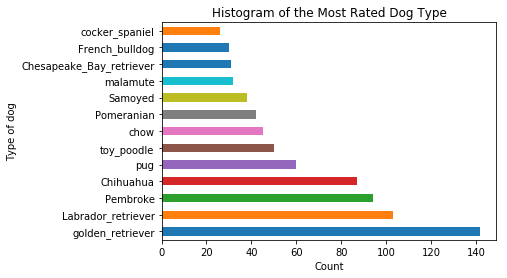

```python
df_dog_type = df_twitter.groupby('dog_type').filter(lambda x: len(x) >= 25)

df_dog_type['dog_type'].value_counts().plot(kind = 'barh')
plt.title('Histogram of the Most Rated Dog Type')
plt.xlabel('Count')
plt.ylabel('Type of dog')

fig = plt.gcf()
fig.savefig('output.png',bbox_inches='tight');
```

### Insight two

```python
df_dog_type_mean = df_twitter.groupby('dog_type').mean()
```

```python
df_dog_type_mean.head()
```

| dog_type | tweet_id | rating_numerator | rating_denominator | year | month | day | rating | favorite_count | retweet_count | followers_count | friends_count |
| --- | --- | --- | --- | --- | --- | --- | --- | --- | --- | --- | --- |
| Afghan_hound | 8.095999e+17 | 8.000000 | 10.0 | 2016.500000 | 6.00 | 16.000000 | 8.000000 | NaN | NaN | NaN | NaN |
| Airedale | 7.184489e+17 | 9.833333 | 10.0 | 2015.583333 | 8.75 | 15.916667 | 9.833333 | NaN | NaN | NaN | NaN |
| American_Staffordshire_terrier | 7.597284e+17 | 10.312500 | 10.0 | 2016.187500 | 5.25 | 15.000000 | 10.312500 | NaN | NaN | NaN | NaN |
| Appenzeller | 7.939334e+17 | 11.000000 | 10.0 | 2016.500000 | 4.50 | 18.500000 | 11.000000 | NaN | NaN | NaN | NaN |
| Australian_terrier | 7.785921e+17 | 11.500000 | 10.0 | 2016.500000 | 3.50 | 7.000000 | 11.500000 | NaN | NaN | NaN | NaN |

```python
df_dog_type_sorted = df_dog_type_mean['rating'].sort_values()

df_dog_type_sorted
```

```
dog_type
Japanese_spaniel                5.000000
Afghan_hound                    8.000000
soft-coated_wheaten_terrier     8.800000
Walker_hound                    9.000000
Scotch_terrier                  9.000000
Tibetan_terrier                 9.250000
dalmatian                       9.272727
Boston_bull                     9.416667
Saint_Bernard                   9.500000
Welsh_springer_spaniel          9.500000
Dandie_Dinmont                  9.571429
Norwich_terrier                 9.600000
miniature_schnauzer             9.600000
redbone                         9.666667
English_setter                  9.714286
Maltese_dog                     9.736842
Rhodesian_ridgeback             9.750000
Scottish_deerhound              9.750000
Irish_terrier                   9.800000
Airedale                        9.833333
papillon                        9.833333
Newfoundland                    9.857143
Mexican_hairless                9.857143
miniature_poodle                9.875000
miniature_pinscher              9.916667
Brabancon_griffon              10.000000
Italian_greyhound              10.000000
groenendael                    10.000000
Ibizan_hound                   10.000000
beagle                         10.052632
                                 ...
Rottweiler                     11.105263
cocker_spaniel                 11.153846
Labrador_retriever             11.194175
clumber                        11.270000
Bernese_mountain_dog           11.272727
kelpie                         11.307692
Greater_Swiss_Mountain_dog     11.333333
Irish_water_spaniel            11.333333
```

[output cut: 8 more lines]

```
Australian_terrier             11.500000
wire-haired_fox_terrier        11.500000
giant_schnauzer                11.500000
golden_retriever               11.588028
Samoyed                        11.657895
Gordon_setter                  11.750000
silky_terrier                  12.000000
standard_schnauzer             12.000000
Tibetan_mastiff                12.000000
Border_terrier                 12.142857
Irish_setter                   12.333333
briard                         12.333333
Saluki                         12.500000
Bouvier_des_Flandres           13.000000
Name: rating, Length: 113, dtype: float64
```

```python
print(df_twitter.loc[df_twitter.dog_type == 'Japanese_spaniel', 'url'])
```

```
710    NaN
Name: url, dtype: object
```

```python
df_twitter[df_twitter['dog_type'] == 'golden_retriever']
```

|  | tweet_id | text | rating_numerator | rating_denominator | name | dogs_stage | year | month | day | rating | jpg_url | dog_type | confidence_list | favorite_count | retweet_count | followers_count | friends_count | source | retweeted_status | url |
| --- | --- | --- | --- | --- | --- | --- | --- | --- | --- | --- | --- | --- | --- | --- | --- | --- | --- | --- | --- | --- |
| 8 | 667530908589760512 | Meet Naphaniel. He doesn't necessarily enjoy h... | 10.0 | 10.0 | Naphaniel | None | 2015 | 11 | 20 | 10.0 | https://pbs.twimg.com/media/CUOL0uGUkAAx7yh.jpg | golden_retriever | 0.633037 | NaN | NaN | NaN | NaN | NaN | NaN | NaN |
| 30 | 667044094246576128 | 12/10 gimme now https://t.co/QZAnwgnOMB | 12.0 | 10.0 | None | None | 2015 | 11 | 18 | 12.0 | https://pbs.twimg.com/media/CUHREBXXAAE6A9b.jpg | golden_retriever | 0.765266 | NaN | NaN | NaN | NaN | NaN | NaN | NaN |
| 37 | 667160273090932737 | This is Bradlay. He is a Ronaldinho Matsuyama ... | 11.0 | 10.0 | Bradlay | None | 2015 | 11 | 19 | 11.0 | https://pbs.twimg.com/media/CUI6uuaW4AAvCIs.jpg | golden_retriever | 0.471351 | NaN | NaN | NaN | NaN | NaN | NaN | NaN |
| 43 | 667182792070062081 | This is Timison. He just told an awful joke bu... | 10.0 | 10.0 | Timison | None | 2015 | 11 | 19 | 10.0 | https://pbs.twimg.com/media/CUJPNjOWsAAZRqP.jpg | golden_retriever | 0.949892 | NaN | NaN | NaN | NaN | NaN | NaN | NaN |
| 46 | 667211855547486208 | This is Genevieve. She is a golden retriever c... | 9.0 | 10.0 | Genevieve | None | 2015 | 11 | 19 | 9.0 | https://pbs.twimg.com/media/CUJppKJWoAA75NP.jpg | golden_retriever | 0.462556 | NaN | NaN | NaN | NaN | NaN | NaN | NaN |
| 62 | 668286279830867968 | Meet Rusty. Rusty's dreaming of a world where ... | 11.0 | 10.0 | Rusty | None | 2015 | 11 | 22 | 11.0 | https://pbs.twimg.com/media/CUY60usWoAAdBxx.jpg | golden_retriever | 0.215944 | NaN | NaN | NaN | NaN | NaN | NaN | NaN |
| 76 | 666345417576210432 | Look at this jokester thinking seat belt laws ... | 10.0 | 10.0 | None | None | 2015 | 11 | 16 | 10.0 | https://pbs.twimg.com/media/CT9Vn7PWoAA_ZCM.jpg | golden_retriever | 0.858744 | NaN | NaN | NaN | NaN | NaN | NaN | NaN |
| 78 | 666063827256086533 | This is the happiest dog you will ever see. Ve... | 10.0 | 10.0 | the | None | 2015 | 11 | 16 | 10.0 | https://pbs.twimg.com/media/CT5Vg_wXIAAXfnj.jpg | golden_retriever | 0.77593 | NaN | NaN | NaN | NaN | NaN | NaN | NaN |
| 94 | 666057090499244032 | My oh my. This is a rare blond Canadian terrie... | 9.0 | 10.0 | a | None | 2015 | 11 | 16 | 9.0 | https://pbs.twimg.com/media/CT5PY90WoAAQGLo.jpg | golden_retriever | 0.00795896 | NaN | NaN | NaN | NaN | NaN | NaN | NaN |
| 110 | 876484053909872640 | This is Benedict. He wants to thank you for th... | 13.0 | 10.0 | Benedict | None | 2017 | 6 | 18 | 13.0 | https://pbs.twimg.com/media/DCnll_dUQAAkBdG.jpg | golden_retriever | 0.874566 | 18288.0 | 2324.0 | 7966138.0 | 12.0 | Twitter for iPhone | Original tweet | https://t.co/ccBFQU5UWO |
| 128 | 888804989199671297 | This is Zeke. He has a new stick. Very proud o... | 13.0 | 10.0 | Zeke | None | 2017 | 7 | 22 | 13.0 | https://pbs.twimg.com/media/DFWra-3VYAA2piG.jpg | golden_retriever | 0.46976 | NaN | NaN | NaN | NaN | NaN | NaN | NaN |
| 141 | 888917238123831296 | This is Jim. He found a fren. Taught him how t... | 12.0 | 10.0 | Jim | None | 2017 | 7 | 23 | 12.0 | https://pbs.twimg.com/media/DFYRgsOUQAARGhO.jpg | golden_retriever | 0.714719 | 28338.0 | 4351.0 | 7966130.0 | 12.0 | Twitter for iPhone | Original tweet | https://t.co/chxruIOUJN |
| 150 | 880465832366813184 | This is Bella. She had her first beach experie... | 12.0 | 10.0 | Bella | None | 2017 | 6 | 29 | 12.0 | https://pbs.twimg.com/media/DDgK-J4XUAIEV9W.jpg | golden_retriever | 0.913255 | 27769.0 | 6086.0 | 7966135.0 | 12.0 | Twitter for iPhone | Original tweet | https://t.co/4VsFysDmiw |
| 154 | 882045870035918850 | This is Koko. Her owner, inspired by Barney, r... | 13.0 | 10.0 | Koko | None | 2017 | 7 | 4 | 13.0 | https://pbs.twimg.com/media/DD2oCl2WAAEI_4a.jpg | golden_retriever | 0.00694063 | NaN | NaN | NaN | NaN | NaN | NaN | NaN |
| 155 | 882268110199369728 | This is Alfy. You're witnessing his first wate... | 13.0 | 10.0 | Alfy | None | 2017 | 7 | 4 | 13.0 | https://pbs.twimg.com/media/DD5yKdPW0AArzX8.jpg | golden_retriever | 0.762211 | 43714.0 | 11228.0 | 7966134.0 | 12.0 | Twitter for iPhone | Original tweet | https://t.co/fYP5RlutfA |
| 158 | 883117836046086144 | Please only send dogs. We don't rate mechanics... | 13.0 | 10.0 | None | None | 2017 | 7 | 7 | 13.0 | https://pbs.twimg.com/media/DEF2-_hXoAAs62q.jpg | golden_retriever | 0.949562 | 36157.0 | 6449.0 | 7966134.0 | 12.0 | Twitter for iPhone | Original tweet | https://t.co/Se5fZ9wp5E |
| 159 | 883482846933004288 | This is Bella. She hopes her smile made you sm... | 13.5 | 10.0 | Bella | None | 2017 | 7 | 8 | 13.5 | https://pbs.twimg.com/media/DELC9dZXUAADqUk.jpg | golden_retriever | 0.943082 | 44651.0 | 9612.0 | 7966133.0 | 12.0 | Twitter for iPhone | Original tweet | https://t.co/qjrljjt948 |
| 170 | 690735892932222976 | Say hello to Peaches. She's a Dingleberry Zand... | 13.0 | 10.0 | Peaches | None | 2016 | 1 | 23 | 13.0 | https://pbs.twimg.com/media/CZX8nyeVAAEstKM.jpg | golden_retriever | 0.883229 | NaN | NaN | NaN | NaN | NaN | NaN | NaN |
| 171 | 690959652130045952 | This golden is happy to refute the soft mouth ... | 11.0 | 10.0 | None | None | 2016 | 1 | 23 | 11.0 | https://pbs.twimg.com/media/CZbIIM-WkAIPClg.jpg | golden_retriever | 0.862964 | NaN | NaN | NaN | NaN | NaN | NaN | NaN |
| 185 | 692568918515392513 | This is Chester. He's been guarding this pumpk... | 12.0 | 10.0 | Chester | None | 2016 | 1 | 28 | 12.0 | https://pbs.twimg.com/media/CZx_wV2UMAArgsJ.jpg | golden_retriever | 0.636845 | NaN | NaN | NaN | NaN | NaN | NaN | NaN |
| 257 | 684225744407494656 | Two sneaky puppers were not initially seen, mo... | 143.0 | 130.0 | None | None | 2016 | 1 | 5 | 11.0 | https://pbs.twimg.com/media/CX7br3HWsAAQ9L1.jpg | golden_retriever | 0.203249 | NaN | NaN | NaN | NaN | NaN | NaN | NaN |
| 262 | 683098815881154561 | aahhhhkslaldhwnxmzbbs 12/10 for being da smoos... | 12.0 | 10.0 | None | None | 2016 | 1 | 2 | 12.0 | https://pbs.twimg.com/media/CXrawAhWkAAWSxC.jpg | golden_retriever | 0.889848 | NaN | NaN | NaN | NaN | NaN | NaN | NaN |
| 294 | 688385280030670848 | This is Louis. He's takes top-notch selfies. 1... | 12.0 | 10.0 | Louis | None | 2016 | 1 | 16 | 12.0 | https://pbs.twimg.com/media/CY2iwGNWUAI5zWi.jpg | golden_retriever | 0.900437 | NaN | NaN | NaN | NaN | NaN | NaN | NaN |
| 332 | 713900603437621249 | Happy Saturday here's 9 puppers on a bench. 99... | 99.0 | 90.0 | None | None | 2016 | 3 | 27 | 11.0 | https://pbs.twimg.com/media/CehIzzZWQAEyHH5.jpg | golden_retriever | 0.371816 | NaN | NaN | NaN | NaN | NaN | NaN | NaN |
| 344 | 708810915978854401 | This is Mister. He's a wonderful father to his... | 10.0 | 10.0 | Mister | None | 2016 | 3 | 13 | 10.0 | https://pbs.twimg.com/media/CdYzwuYUIAAHPkB.jpg | golden_retriever | 0.976139 | NaN | NaN | NaN | NaN | NaN | NaN | NaN |
| 354 | 709556954897764353 | This is Cecil. She's a Gigglefloof Poofer. Out... | 12.0 | 10.0 | Cecil | None | 2016 | 3 | 15 | 12.0 | https://pbs.twimg.com/media/CdjaSFCWAAAJZh3.jpg | golden_retriever | 0.790026 | NaN | NaN | NaN | NaN | NaN | NaN | NaN |
| 370 | 718971898235854848 | This is Sadie. She is prepared for battle. 10/... | 10.0 | 10.0 | Sadie | None | 2016 | 4 | 10 | 10.0 | https://pbs.twimg.com/media/CfpNGTHUIAAA8XC.jpg | golden_retriever | 0.140394 | NaN | NaN | NaN | NaN | NaN | NaN | NaN |
| 372 | 719339463458033665 | Say hello to Lucy and Sophie. They think they'... | 10.0 | 10.0 | Lucy | None | 2016 | 4 | 11 | 10.0 | https://pbs.twimg.com/media/Cfuba6NW4AIeMHk.jpg | golden_retriever | 0.765778 | NaN | NaN | NaN | NaN | NaN | NaN | NaN |
| 385 | 723673163800948736 | This is Ivar. She is a badass Viking warrior. ... | 10.0 | 10.0 | Ivar | None | 2016 | 4 | 23 | 10.0 | https://pbs.twimg.com/media/CgsA5eFWgAAu0qn.jpg | golden_retriever | 0.83939 | NaN | NaN | NaN | NaN | NaN | NaN | NaN |
| 398 | 715680795826982913 | This is Zeus. He's downright fabulous. 12/10 h... | 12.0 | 10.0 | Zeus | None | 2016 | 3 | 31 | 12.0 | https://pbs.twimg.com/media/Ce6b4MPWwAA22Xm.jpg | golden_retriever | 0.990715 | NaN | NaN | NaN | NaN | NaN | NaN | NaN |
| ... | ... | ... | ... | ... | ... | ... | ... | ... | ... | ... | ... | ... | ... | ... | ... | ... | ... | ... | ... | ... |
| 1376 | 846514051647705089 | This is Barney. He's an elder doggo. Hitches a... | 13.0 | 10.0 | Barney | doggo | 2017 | 3 | 28 | 13.0 | https://pbs.twimg.com/media/C79sB4xXwAEvwKY.jpg | golden_retriever | 0.650003 | NaN | NaN | NaN | NaN | NaN | NaN | NaN |
| 1381 | 834574053763584002 | Here's a doggo fully pupared for a shower. H*c... | 13.0 | 10.0 | None | doggo | 2017 | 2 | 23 | 13.0 | https://pbs.twimg.com/media/C5UAqgyXAAAbMWH.jpg | golden_retriever | 0.226564 | NaN | NaN | NaN | NaN | NaN | NaN | NaN |
| 1382 | 719991154352222208 | This doggo was initially thrilled when she saw... | 10.0 | 10.0 | None | doggo | 2016 | 4 | 12 | 10.0 | https://pbs.twimg.com/media/Cf3sH62VAAA-LiP.jpg | golden_retriever | 0.605304 | NaN | NaN | NaN | NaN | NaN | NaN | NaN |
| 1391 | 716080869887381504 | Here's a super majestic doggo and a sunset 11/... | 11.0 | 10.0 | None | doggo | 2016 | 4 | 2 | 11.0 | https://pbs.twimg.com/media/CfAHv83UMAIEQYx.jpg | golden_retriever | 0.638625 | NaN | NaN | NaN | NaN | NaN | NaN | NaN |
| 1393 | 795464331001561088 | Elder doggo does a splash. Both 13/10 incredib... | 13.0 | 10.0 | None | doggo | 2016 | 11 | 7 | 13.0 | https://pbs.twimg.com/ext_tw_video_thumb/79546... | golden_retriever | 0.193082 | NaN | NaN | NaN | NaN | NaN | NaN | NaN |
| 1395 | 786363235746385920 | This is Rizzo. He has many talents. A true ren... | 13.0 | 10.0 | Rizzo | doggo | 2016 | 10 | 13 | 13.0 | https://pbs.twimg.com/media/Cum5LlfWAAAyPcS.jpg | golden_retriever | 0.929266 | NaN | NaN | NaN | NaN | NaN | NaN | NaN |
| 1403 | 782747134529531904 | This is Deacon. He's the happiest almost dry d... | 11.0 | 10.0 | Deacon | doggo | 2016 | 10 | 3 | 11.0 | https://pbs.twimg.com/media/CtzgXgeXYAA1Gxw.jpg | golden_retriever | 0.560699 | NaN | NaN | NaN | NaN | NaN | NaN | NaN |
| 1418 | 858843525470990336 | I have stumbled puppon a doggo painting party.... | 13.0 | 10.0 | None | doggo | 2017 | 5 | 1 | 13.0 | https://pbs.twimg.com/media/C-s5oYZXkAAMHHq.jpg | golden_retriever | 0.57812 | NaN | NaN | NaN | NaN | NaN | NaN | NaN |
| 1419 | 821765923262631936 | This is Duchess. She uses dark doggo forces to... | 13.0 | 10.0 | Duchess | doggo | 2017 | 1 | 18 | 13.0 | https://pbs.twimg.com/media/C2d_vnHWEAE9phX.jpg | golden_retriever | 0.980071 | NaN | NaN | NaN | NaN | NaN | NaN | NaN |
| 1429 | 800388270626521089 | This is Doc. He takes time out of every day to... | 12.0 | 10.0 | Doc | floofer | 2016 | 11 | 20 | 12.0 | https://pbs.twimg.com/media/CxuM3oZW8AEhO5z.jpg | golden_retriever | 0.35986 | NaN | NaN | NaN | NaN | NaN | NaN | NaN |
| 1443 | 724405726123311104 | This is Ashleigh. She's having Coachella withd... | 10.0 | 10.0 | Ashleigh | pupper | 2016 | 4 | 25 | 10.0 | https://pbs.twimg.com/media/Cg2bKLAWwAA0WEm.jpg | golden_retriever | 0.240695 | NaN | NaN | NaN | NaN | NaN | NaN | NaN |
| 1479 | 678341075375947776 | This pupper likes tape. 12/10 https://t.co/cSp... | 12.0 | 10.0 | None | pupper | 2015 | 12 | 19 | 12.0 | https://pbs.twimg.com/media/CWnznDTU4AAa-6P.jpg | golden_retriever | 0.853284 | NaN | NaN | NaN | NaN | NaN | NaN | NaN |
| 1481 | 676470639084101634 | Three generations of pupper. 11/10 for all htt... | 11.0 | 10.0 | None | pupper | 2015 | 12 | 14 | 11.0 | https://pbs.twimg.com/media/CWNOdIpWoAAWid2.jpg | golden_retriever | 0.790386 | NaN | NaN | NaN | NaN | NaN | NaN | NaN |
| 1498 | 680100725817409536 | This pupper is not coming inside until she cat... | 11.0 | 10.0 | None | pupper | 2015 | 12 | 24 | 11.0 | https://pbs.twimg.com/media/CW-loUBWYAAn2Cb.jpg | golden_retriever | 0.698961 | NaN | NaN | NaN | NaN | NaN | NaN | NaN |
| 1522 | 808106460588765185 | Here we have Burke (pupper) and Dexter (doggo)... | 12.0 | 10.0 | None | pupper | 2016 | 12 | 12 | 12.0 | https://pbs.twimg.com/media/Czb4iFRXgAIUMiN.jpg | golden_retriever | 0.426183 | NaN | NaN | NaN | NaN | NaN | NaN | NaN |
| 1524 | 807621403335917568 | This is Ollie Vue. He was a 3 legged pupper on... | 14.0 | 10.0 | Ollie | pupper | 2016 | 12 | 10 | 14.0 | https://pbs.twimg.com/media/CzU_YVGUUAA3Xsd.jpg | golden_retriever | 0.873233 | NaN | NaN | NaN | NaN | NaN | NaN | NaN |
| 1535 | 751456908746354688 | Here's a pupper that's very hungry but too laz... | 12.0 | 10.0 | None | pupper | 2016 | 7 | 8 | 12.0 | https://pbs.twimg.com/ext_tw_video_thumb/75145... | golden_retriever | 0.714409 | NaN | NaN | NaN | NaN | NaN | NaN | NaN |
| 1537 | 699801817392291840 | This is Cooper. He began to tear up when his b... | 11.0 | 10.0 | Cooper | pupper | 2016 | 2 | 17 | 11.0 | https://pbs.twimg.com/media/CbYyCMcWIAAHHjF.jpg | golden_retriever | 0.808978 | NaN | NaN | NaN | NaN | NaN | NaN | NaN |
| 1540 | 699434518667751424 | I know this is a tad late but here's a wonderf... | 12.0 | 10.0 | None | pupper | 2016 | 2 | 16 | 12.0 | https://pbs.twimg.com/media/CbTj--1XEAIZjc_.jpg | golden_retriever | 0.836572 | NaN | NaN | NaN | NaN | NaN | NaN | NaN |
| 1541 | 673295268553605120 | Meet Eve. She's a raging alcoholic 8/10 (would... | 8.0 | 10.0 | Eve | pupper | 2015 | 12 | 6 | 8.0 | https://pbs.twimg.com/media/CVgGc9hWIAIe1bn.jpg | golden_retriever | 0.889241 | NaN | NaN | NaN | NaN | NaN | NaN | NaN |
| 1551 | 700143752053182464 | When it's Janet from accounting's birthday but... | 10.0 | 10.0 | None | pupper | 2016 | 2 | 18 | 10.0 | https://pbs.twimg.com/media/CbdpBmLUYAY9SgQ.jpg | golden_retriever | 0.53246 | NaN | NaN | NaN | NaN | NaN | NaN | NaN |
| 1553 | 672622327801233409 | This lil pupper is sad because we haven't foun... | 12.0 | 10.0 | None | pupper | 2015 | 12 | 4 | 12.0 | https://pbs.twimg.com/media/CVWicBbUYAIomjC.jpg | golden_retriever | 0.952773 | NaN | NaN | NaN | NaN | NaN | NaN | NaN |
| 1573 | 756939218950160384 | This is Jax. He is a majestic mountain pupper.... | 12.0 | 10.0 | Jax | pupper | 2016 | 7 | 23 | 12.0 | https://pbs.twimg.com/media/CoEwMXeWEAAaIz5.jpg | golden_retriever | 0.790371 | NaN | NaN | NaN | NaN | NaN | NaN | NaN |
| 1579 | 837820167694528512 | Here's a pupper before and after being asked "... | 12.0 | 10.0 | None | pupper | 2017 | 3 | 4 | 12.0 | https://pbs.twimg.com/media/C6CI_jbVAAA3-a1.jpg | golden_retriever | 0.887625 | NaN | NaN | NaN | NaN | NaN | NaN | NaN |
| 1584 | 765371061932261376 | This is Louie. He's had a long day. Did a lot ... | 11.0 | 10.0 | Louie | pupper | 2016 | 8 | 16 | 11.0 | https://pbs.twimg.com/media/Cp8k6oRWcAUL78U.jpg | golden_retriever | 0.829456 | NaN | NaN | NaN | NaN | NaN | NaN | NaN |
| 1585 | 693262851218264065 | I hope you guys enjoy this beautiful snowy pup... | 11.0 | 10.0 | None | pupper | 2016 | 1 | 30 | 11.0 | https://pbs.twimg.com/media/CZ724fDUYAAytS-.jpg | golden_retriever | 0.989333 | NaN | NaN | NaN | NaN | NaN | NaN | NaN |
| 1588 | 675740360753160193 | Here's a pupper licking in slow motion. 12/10 ... | 12.0 | 10.0 | None | pupper | 2015 | 12 | 12 | 12.0 | https://pbs.twimg.com/ext_tw_video_thumb/67574... | golden_retriever | 0.800495 | NaN | NaN | NaN | NaN | NaN | NaN | NaN |
| 1598 | 759793422261743616 | Meet Maggie &amp; Lila. Maggie is the doggo, L... | 12.0 | 10.0 | Maggie | pupper | 2016 | 7 | 31 | 12.0 | https://pbs.twimg.com/media/CotUFZEWcAA2Pku.jpg | golden_retriever | 0.985876 | NaN | NaN | NaN | NaN | NaN | NaN | NaN |
| 1615 | 859607811541651456 | Sorry for the lack of posts today. I came home... | 13.0 | 10.0 | None | puppo | 2017 | 5 | 3 | 13.0 | https://pbs.twimg.com/media/C-3wvtxXcAUTuBE.jpg | golden_retriever | 0.895529 | NaN | NaN | NaN | NaN | NaN | NaN | NaN |
| 1617 | 889531135344209921 | This is Stuart. He's sporting his favorite fan... | 13.0 | 10.0 | Stuart | puppo | 2017 | 7 | 24 | 13.0 | https://pbs.twimg.com/media/DFg_2PVW0AEHN3p.jpg | golden_retriever | 0.953442 | NaN | NaN | NaN | NaN | NaN | NaN | NaN |

142 rows × 20 columns

### Insight three & visualization

Dog_types with low number of ratings show a high variaty of mean ratings.

```python
df_dog_type_count = df_twitter.groupby('dog_type').count()
df_dog_type_count
```

| dog_type | tweet_id | text | rating_numerator | rating_denominator | name | dogs_stage | year | month | day | rating | jpg_url | confidence_list | favorite_count | retweet_count | followers_count | friends_count | source | retweeted_status | url |
| --- | --- | --- | --- | --- | --- | --- | --- | --- | --- | --- | --- | --- | --- | --- | --- | --- | --- | --- | --- |
| Afghan_hound | 2 | 2 | 2 | 2 | 2 | 2 | 2 | 2 | 2 | 2 | 2 | 2 | 0 | 0 | 0 | 0 | 0 | 0 | 0 |
| Airedale | 12 | 12 | 12 | 12 | 12 | 12 | 12 | 12 | 12 | 12 | 12 | 12 | 0 | 0 | 0 | 0 | 0 | 0 | 0 |
| American_Staffordshire_terrier | 16 | 16 | 16 | 16 | 16 | 16 | 16 | 16 | 16 | 16 | 16 | 16 | 0 | 0 | 0 | 0 | 0 | 0 | 0 |
| Appenzeller | 2 | 2 | 2 | 2 | 2 | 2 | 2 | 2 | 2 | 2 | 2 | 2 | 0 | 0 | 0 | 0 | 0 | 0 | 0 |
| Australian_terrier | 2 | 2 | 2 | 2 | 2 | 2 | 2 | 2 | 2 | 2 | 2 | 2 | 0 | 0 | 0 | 0 | 0 | 0 | 0 |
| Bedlington_terrier | 6 | 6 | 6 | 6 | 6 | 6 | 6 | 6 | 6 | 6 | 6 | 6 | 0 | 0 | 0 | 0 | 0 | 0 | 0 |
| Bernese_mountain_dog | 11 | 11 | 11 | 11 | 11 | 11 | 11 | 11 | 11 | 11 | 11 | 11 | 1 | 1 | 1 | 1 | 1 | 1 | 1 |
| Blenheim_spaniel | 10 | 10 | 10 | 10 | 10 | 10 | 10 | 10 | 10 | 10 | 10 | 10 | 1 | 1 | 1 | 1 | 1 | 1 | 1 |
| Border_collie | 12 | 12 | 12 | 12 | 12 | 12 | 12 | 12 | 12 | 12 | 12 | 12 | 0 | 0 | 0 | 0 | 0 | 0 | 0 |
| Border_terrier | 7 | 7 | 7 | 7 | 7 | 7 | 7 | 7 | 7 | 7 | 7 | 7 | 0 | 0 | 0 | 0 | 0 | 0 | 0 |
| Boston_bull | 12 | 12 | 12 | 12 | 12 | 12 | 12 | 12 | 12 | 12 | 12 | 12 | 0 | 0 | 0 | 0 | 0 | 0 | 0 |
| Bouvier_des_Flandres | 1 | 1 | 1 | 1 | 1 | 1 | 1 | 1 | 1 | 1 | 1 | 1 | 0 | 0 | 0 | 0 | 0 | 0 | 0 |
| Brabancon_griffon | 3 | 3 | 3 | 3 | 3 | 3 | 3 | 3 | 3 | 3 | 3 | 3 | 0 | 0 | 0 | 0 | 0 | 0 | 0 |
| Brittany_spaniel | 8 | 8 | 8 | 8 | 8 | 8 | 8 | 8 | 8 | 8 | 8 | 8 | 0 | 0 | 0 | 0 | 0 | 0 | 0 |
| Cardigan | 19 | 19 | 19 | 19 | 19 | 19 | 19 | 19 | 19 | 19 | 19 | 19 | 0 | 0 | 0 | 0 | 0 | 0 | 0 |
| Chesapeake_Bay_retriever | 31 | 31 | 31 | 31 | 31 | 31 | 31 | 31 | 31 | 31 | 31 | 31 | 2 | 2 | 2 | 2 | 2 | 2 | 2 |
| Chihuahua | 87 | 87 | 87 | 87 | 87 | 87 | 87 | 87 | 87 | 87 | 87 | 87 | 3 | 3 | 3 | 3 | 3 | 3 | 3 |
| Dandie_Dinmont | 7 | 7 | 7 | 7 | 7 | 7 | 7 | 7 | 7 | 7 | 7 | 7 | 0 | 0 | 0 | 0 | 0 | 0 | 0 |
| Doberman | 9 | 9 | 9 | 9 | 9 | 9 | 9 | 9 | 9 | 9 | 9 | 9 | 0 | 0 | 0 | 0 | 0 | 0 | 0 |
| English_setter | 7 | 7 | 7 | 7 | 7 | 7 | 7 | 7 | 7 | 7 | 7 | 7 | 0 | 0 | 0 | 0 | 0 | 0 | 0 |
| English_springer | 9 | 9 | 9 | 9 | 9 | 9 | 9 | 9 | 9 | 9 | 9 | 9 | 0 | 0 | 0 | 0 | 0 | 0 | 0 |
| EntleBucher | 1 | 1 | 1 | 1 | 1 | 1 | 1 | 1 | 1 | 1 | 1 | 1 | 0 | 0 | 0 | 0 | 0 | 0 | 0 |
| Eskimo_dog | 22 | 22 | 22 | 22 | 22 | 22 | 22 | 22 | 22 | 22 | 22 | 22 | 1 | 1 | 1 | 1 | 1 | 1 | 1 |
| French_bulldog | 30 | 30 | 30 | 30 | 30 | 30 | 30 | 30 | 30 | 30 | 30 | 30 | 4 | 4 | 4 | 4 | 4 | 4 | 4 |
| German_shepherd | 21 | 21 | 21 | 21 | 21 | 21 | 21 | 21 | 21 | 21 | 21 | 21 | 0 | 0 | 0 | 0 | 0 | 0 | 0 |
| German_short-haired_pointer | 8 | 8 | 8 | 8 | 8 | 8 | 8 | 8 | 8 | 8 | 8 | 8 | 1 | 1 | 1 | 1 | 1 | 1 | 1 |
| Gordon_setter | 4 | 4 | 4 | 4 | 4 | 4 | 4 | 4 | 4 | 4 | 4 | 4 | 0 | 0 | 0 | 0 | 0 | 0 | 0 |
| Great_Dane | 11 | 11 | 11 | 11 | 11 | 11 | 11 | 11 | 11 | 11 | 11 | 11 | 0 | 0 | 0 | 0 | 0 | 0 | 0 |
| Great_Pyrenees | 15 | 15 | 15 | 15 | 15 | 15 | 15 | 15 | 15 | 15 | 15 | 15 | 0 | 0 | 0 | 0 | 0 | 0 | 0 |
| Greater_Swiss_Mountain_dog | 3 | 3 | 3 | 3 | 3 | 3 | 3 | 3 | 3 | 3 | 3 | 3 | 0 | 0 | 0 | 0 | 0 | 0 | 0 |
| ... | ... | ... | ... | ... | ... | ... | ... | ... | ... | ... | ... | ... | ... | ... | ... | ... | ... | ... | ... |
| cocker_spaniel | 26 | 26 | 26 | 26 | 26 | 26 | 26 | 26 | 26 | 26 | 26 | 26 | 0 | 0 | 0 | 0 | 0 | 0 | 0 |
| collie | 11 | 11 | 11 | 11 | 11 | 11 | 11 | 11 | 11 | 11 | 11 | 11 | 0 | 0 | 0 | 0 | 0 | 0 | 0 |
| curly-coated_retriever | 3 | 3 | 3 | 3 | 3 | 3 | 3 | 3 | 3 | 3 | 3 | 3 | 0 | 0 | 0 | 0 | 0 | 0 | 0 |
| dalmatian | 11 | 11 | 11 | 11 | 11 | 11 | 11 | 11 | 11 | 11 | 11 | 11 | 0 | 0 | 0 | 0 | 0 | 0 | 0 |
| flat-coated_retriever | 8 | 8 | 8 | 8 | 8 | 8 | 8 | 8 | 8 | 8 | 8 | 8 | 0 | 0 | 0 | 0 | 0 | 0 | 0 |
| giant_schnauzer | 4 | 4 | 4 | 4 | 4 | 4 | 4 | 4 | 4 | 4 | 4 | 4 | 0 | 0 | 0 | 0 | 0 | 0 | 0 |
| golden_retriever | 142 | 142 | 142 | 142 | 142 | 142 | 142 | 142 | 142 | 142 | 142 | 142 | 6 | 6 | 6 | 6 | 6 | 6 | 6 |
| groenendael | 2 | 2 | 2 | 2 | 2 | 2 | 2 | 2 | 2 | 2 | 2 | 2 | 0 | 0 | 0 | 0 | 0 | 0 | 0 |
| keeshond | 4 | 4 | 4 | 4 | 4 | 4 | 4 | 4 | 4 | 4 | 4 | 4 | 0 | 0 | 0 | 0 | 0 | 0 | 0 |
| kelpie | 13 | 13 | 13 | 13 | 13 | 13 | 13 | 13 | 13 | 13 | 13 | 13 | 0 | 0 | 0 | 0 | 0 | 0 | 0 |
| komondor | 3 | 3 | 3 | 3 | 3 | 3 | 3 | 3 | 3 | 3 | 3 | 3 | 0 | 0 | 0 | 0 | 0 | 0 | 0 |
| kuvasz | 18 | 18 | 18 | 18 | 18 | 18 | 18 | 18 | 18 | 18 | 18 | 18 | 1 | 1 | 1 | 1 | 1 | 1 | 1 |
| malamute | 32 | 32 | 32 | 32 | 32 | 32 | 32 | 32 | 32 | 32 | 32 | 32 | 1 | 1 | 1 | 1 | 1 | 1 | 1 |
| malinois | 11 | 11 | 11 | 11 | 11 | 11 | 11 | 11 | 11 | 11 | 11 | 11 | 0 | 0 | 0 | 0 | 0 | 0 | 0 |
| miniature_pinscher | 24 | 24 | 24 | 24 | 24 | 24 | 24 | 24 | 24 | 24 | 24 | 24 | 0 | 0 | 0 | 0 | 0 | 0 | 0 |
| miniature_poodle | 8 | 8 | 8 | 8 | 8 | 8 | 8 | 8 | 8 | 8 | 8 | 8 | 0 | 0 | 0 | 0 | 0 | 0 | 0 |
| miniature_schnauzer | 5 | 5 | 5 | 5 | 5 | 5 | 5 | 5 | 5 | 5 | 5 | 5 | 0 | 0 | 0 | 0 | 0 | 0 | 0 |
| papillon | 6 | 6 | 6 | 6 | 6 | 6 | 6 | 6 | 6 | 6 | 6 | 6 | 0 | 0 | 0 | 0 | 0 | 0 | 0 |
| pug | 60 | 60 | 60 | 60 | 60 | 60 | 60 | 60 | 60 | 60 | 60 | 60 | 2 | 2 | 2 | 2 | 2 | 2 | 2 |
| redbone | 6 | 6 | 6 | 6 | 6 | 6 | 6 | 6 | 6 | 6 | 6 | 6 | 0 | 0 | 0 | 0 | 0 | 0 | 0 |
| schipperke | 11 | 11 | 11 | 11 | 11 | 11 | 11 | 11 | 11 | 11 | 11 | 11 | 0 | 0 | 0 | 0 | 0 | 0 | 0 |
| silky_terrier | 1 | 1 | 1 | 1 | 1 | 1 | 1 | 1 | 1 | 1 | 1 | 1 | 0 | 0 | 0 | 0 | 0 | 0 | 0 |
| soft-coated_wheaten_terrier | 15 | 15 | 15 | 15 | 15 | 15 | 15 | 15 | 15 | 15 | 15 | 15 | 0 | 0 | 0 | 0 | 0 | 0 | 0 |
| standard_poodle | 10 | 10 | 10 | 10 | 10 | 10 | 10 | 10 | 10 | 10 | 10 | 10 | 0 | 0 | 0 | 0 | 0 | 0 | 0 |
| standard_schnauzer | 1 | 1 | 1 | 1 | 1 | 1 | 1 | 1 | 1 | 1 | 1 | 1 | 0 | 0 | 0 | 0 | 0 | 0 | 0 |
| toy_poodle | 50 | 50 | 50 | 50 | 50 | 50 | 50 | 50 | 50 | 50 | 50 | 50 | 0 | 0 | 0 | 0 | 0 | 0 | 0 |
| toy_terrier | 3 | 3 | 3 | 3 | 3 | 3 | 3 | 3 | 3 | 3 | 3 | 3 | 0 | 0 | 0 | 0 | 0 | 0 | 0 |
| vizsla | 13 | 13 | 13 | 13 | 13 | 13 | 13 | 13 | 13 | 13 | 13 | 13 | 0 | 0 | 0 | 0 | 0 | 0 | 0 |
| whippet | 11 | 11 | 11 | 11 | 11 | 11 | 11 | 11 | 11 | 11 | 11 | 11 | 1 | 1 | 1 | 1 | 1 | 1 | 1 |
| wire-haired_fox_terrier | 2 | 2 | 2 | 2 | 2 | 2 | 2 | 2 | 2 | 2 | 2 | 2 | 0 | 0 | 0 | 0 | 0 | 0 | 0 |

113 rows × 19 columns

```python
dog_type_count = df_dog_type_count['rating']
dog_type_mean = df_dog_type_mean['rating']
dog_type_mean
```

```
dog_type
Afghan_hound                       8.000000
Airedale                           9.833333
American_Staffordshire_terrier    10.312500
Appenzeller                       11.000000
Australian_terrier                11.500000
Bedlington_terrier                10.333333
Bernese_mountain_dog              11.272727
Blenheim_spaniel                  11.100000
Border_collie                     10.583333
Border_terrier                    12.142857
Boston_bull                        9.416667
Bouvier_des_Flandres              13.000000
Brabancon_griffon                 10.000000
Brittany_spaniel                  10.375000
Cardigan                          11.105263
Chesapeake_Bay_retriever          10.838710
Chihuahua                         10.448276
Dandie_Dinmont                     9.571429
Doberman                          11.333333
English_setter                     9.714286
English_springer                  10.555556
EntleBucher                       11.000000
Eskimo_dog                        11.409091
French_bulldog                    11.100000
German_shepherd                   11.000000
German_short-haired_pointer       10.500000
Gordon_setter                     11.750000
Great_Dane                        10.818182
Great_Pyrenees                    11.466667
Greater_Swiss_Mountain_dog        11.333333
                                    ...
cocker_spaniel                    11.153846
collie                            10.909091
curly-coated_retriever            10.333333
dalmatian                          9.272727
flat-coated_retriever             10.875000
giant_schnauzer                   11.500000
golden_retriever                  11.588028
groenendael                       10.000000
```

[output cut: 8 more lines]

```
miniature_schnauzer                9.600000
papillon                           9.833333
pug                               10.200000
redbone                            9.666667
schipperke                        10.818182
silky_terrier                     12.000000
soft-coated_wheaten_terrier        8.800000
standard_poodle                   10.400000
standard_schnauzer                12.000000
toy_poodle                        11.020000
toy_terrier                       10.333333
vizsla                            10.846154
whippet                           10.181818
wire-haired_fox_terrier           11.500000
Name: rating, Length: 113, dtype: float64
```

```python
df = pd.DataFrame()
df['dog_type_count'] = dog_type_count
df['dog_type_mean'] = dog_type_mean
df
```

| dog_type | dog_type_count | dog_type_mean |
| --- | --- | --- |
| Afghan_hound | 2 | 8.000000 |
| Airedale | 12 | 9.833333 |
| American_Staffordshire_terrier | 16 | 10.312500 |
| Appenzeller | 2 | 11.000000 |
| Australian_terrier | 2 | 11.500000 |
| Bedlington_terrier | 6 | 10.333333 |
| Bernese_mountain_dog | 11 | 11.272727 |
| Blenheim_spaniel | 10 | 11.100000 |
| Border_collie | 12 | 10.583333 |
| Border_terrier | 7 | 12.142857 |
| Boston_bull | 12 | 9.416667 |
| Bouvier_des_Flandres | 1 | 13.000000 |
| Brabancon_griffon | 3 | 10.000000 |
| Brittany_spaniel | 8 | 10.375000 |
| Cardigan | 19 | 11.105263 |
| Chesapeake_Bay_retriever | 31 | 10.838710 |
| Chihuahua | 87 | 10.448276 |
| Dandie_Dinmont | 7 | 9.571429 |
| Doberman | 9 | 11.333333 |
| English_setter | 7 | 9.714286 |
| English_springer | 9 | 10.555556 |
| EntleBucher | 1 | 11.000000 |
| Eskimo_dog | 22 | 11.409091 |
| French_bulldog | 30 | 11.100000 |
| German_shepherd | 21 | 11.000000 |
| German_short-haired_pointer | 8 | 10.500000 |
| Gordon_setter | 4 | 11.750000 |
| Great_Dane | 11 | 10.818182 |
| Great_Pyrenees | 15 | 11.466667 |
| Greater_Swiss_Mountain_dog | 3 | 11.333333 |
| ... | ... | ... |
| cocker_spaniel | 26 | 11.153846 |
| collie | 11 | 10.909091 |
| curly-coated_retriever | 3 | 10.333333 |
| dalmatian | 11 | 9.272727 |
| flat-coated_retriever | 8 | 10.875000 |
| giant_schnauzer | 4 | 11.500000 |
| golden_retriever | 142 | 11.588028 |
| groenendael | 2 | 10.000000 |
| keeshond | 4 | 10.250000 |
| kelpie | 13 | 11.307692 |
| komondor | 3 | 11.000000 |
| kuvasz | 18 | 10.792222 |
| malamute | 32 | 10.875000 |
| malinois | 11 | 10.818182 |
| miniature_pinscher | 24 | 9.916667 |
| miniature_poodle | 8 | 9.875000 |
| miniature_schnauzer | 5 | 9.600000 |
| papillon | 6 | 9.833333 |
| pug | 60 | 10.200000 |
| redbone | 6 | 9.666667 |
| schipperke | 11 | 10.818182 |
| silky_terrier | 1 | 12.000000 |
| soft-coated_wheaten_terrier | 15 | 8.800000 |
| standard_poodle | 10 | 10.400000 |
| standard_schnauzer | 1 | 12.000000 |
| toy_poodle | 50 | 11.020000 |
| toy_terrier | 3 | 10.333333 |
| vizsla | 13 | 10.846154 |
| whippet | 11 | 10.181818 |
| wire-haired_fox_terrier | 2 | 11.500000 |

113 rows × 2 columns

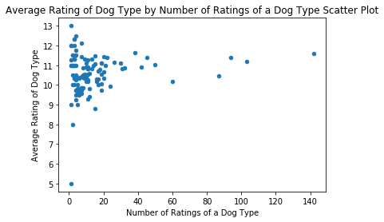

```python
df.plot(x='dog_type_count', y='dog_type_mean', kind='scatter')
plt.xlabel('Number of Ratings of a Dog Type')
plt.ylabel('Average Rating of Dog Type')
plt.title('Average Rating of Dog Type by Number of Ratings of a Dog Type Scatter Plot')

fig = plt.gcf()
#plt.savefig('X:/' + newName + '.png',
fig.savefig('output2.png',bbox_inches='tight');
```

### Insight four & visualization

The highest ratings do not receive the most retweets.

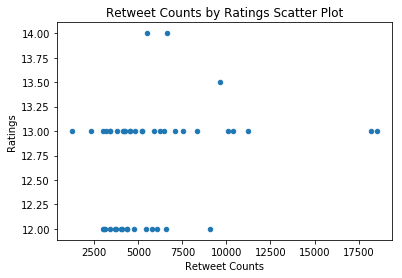

```python
df_twitter.plot(x='retweet_count', y='rating', kind='scatter')
plt.xlabel('Retweet Counts')
plt.ylabel('Ratings')
plt.title('Retweet Counts by Ratings Scatter Plot')

fig = plt.gcf()
fig.savefig('output3.png',bbox_inches='tight');
```